# property_recommender_system

## Recommender System for Vehicles and Real Estate

Project Overview:  
This project aims to develop an AI-based recommendation system that delivers personalized recommendations for vehicles and real estate. The system will consider user interaction data and item features to suggest products tailored to individual needs. In our case, we start with a real estate dataset from the USA, while integrating concepts that can later be adapted to vehicles.

Integration:  
A Flask-based REST API will interface with our existing ASP Core backend to provide real-time recommendations.

Dataset:  
We will begin working with a real estate dataset from Kaggle which contains US housing listings with features such as price, number of beds, bathrooms, lot size, and location details.

## Referential Study of Relevant Research Papers

Below is a comprehensive review and comparison of all five papers. This review covers the core concept behind each paper, the specific recommendation problem they target, the steps they take to design their systems, the data and models they use, their evaluation methodologies, final outcomes, and the distinguishing aspects of each approach.

## Paper 1: Fuzzy Logic, Geospatial Analysis, and Metaheuristic Optimization

### Concept and Target Problem

- Concept: A hybrid recommendation system for real estate that uses fuzzy logic to handle uncertainty in user preferences. It integrates content-based and collaborative filtering to improve recommendation accuracy, particularly in dealing with subtle, qualitative aspects (e.g., “somewhat affordable”) and incorporates spatial aspects.
- Target Problem: Helps users find housing that satisfies both quantitative features (e.g., price, size, age) and qualitative, uncertain preferences (e.g., safety, comfort) while also factoring in location-based attributes (like proximity to schools or hospitals).

### Steps and Detailed Methodology

- Core Technologies:
  - Fuzzy Logic:
    - Fuzzy C-Means (FCM) Clustering assigns properties to multiple clusters with soft membership scores.
    - Membership Functions handle user descriptions with ambiguous terms.
  - Geospatial Analysis:
    - Uses tools like QGIS or Python libraries (e.g., geopy) to compute distances between properties and key points (schools, hospitals).
  - Hybrid Filtering:
    - Content-Based Filtering: Uses property features (price, size, age, geospatial distances) to group similar houses.
    - Collaborative Filtering: Leverages user ratings and interactions to refine recommendations.
  - Metaheuristic Optimization:
    - Bat Algorithm (or alternatives like PSO or GA) is used to optimize the candidate search process by mimicking bat echolocation for faster convergence.
- Data Used:
  - Housing Features: Scraped using Selenium or Scrapy from real estate websites (e.g., Zillow or local platforms).
  - Geospatial Data: Collected via QGIS and APIs (e.g., Google Maps) to obtain latitude/longitude and compute distances.
  - User Data: Preferences, ratings, and interaction logs stored in SQLite or similar relational databases.
- Models and Algorithms:
  - Fuzzy C-Means for clustering houses.
  - Matrix factorization or k–NN for collaborative filtering.
  - Bat Algorithm to reduce search time and optimize selection from multiple clusters.
- Evaluation:
  - Metrics include precision, recall, diversity, and user satisfaction.
  - A/B testing is used to compare fuzzy logic–based recommendations with traditional methods (for example, using Pearson correlation).
- Results and Distinguishing Features:
  - Outcome: The system produces personalized property recommendations that accommodate ambiguous user preferences and geographical constraints.
  - Distinguishing Factors:
    - Integration of fuzzy logic enables soft, non-binary classification.
    - Use of geospatial analysis adds a practical dimension by considering distances.
    - Metaheuristic optimization (Bat Algorithm) offers a novel way to speed up selection across soft clusters.

## Paper 2: Rule-Based Engine, Content Filtering, and Hybrid Approaches

### Concept and Target Problem

- Concept: Develops a robust real estate recommender called RE-RecSys that blends rule-based methods with content and collaborative filtering to balance short-term (recent user actions) and long-term preferences.
- Target Problem: Addresses the cold-start problem and real-time performance. It combines different recommendation strategies to deliver accurate and fast recommendations for users with varying interaction histories.

### Steps and Detailed Methodology

- Core Technologies:
  - Rule-Based Engine:
    - Categorizes users (e.g., cold-start, short-term, long-term) and applies predefined scoring metrics to guide recommendations initially.
  - Content Filtering:
    - Uses cosine similarity based on recent user actions and item features.
  - Collaborative Filtering:
    - Implements matrix factorization (e.g., Alternating Least Squares, ALS) to extract long-term preferences.
  - Hybrid Models:
    - Integrates both rule-based and filtering models to create balanced recommendations.
  - Scalable Training:
    - Employs Apache Spark ML to handle large datasets in a distributed environment.
  - API Integration:
    - Provides REST APIs (developed in Python/Flask) to deliver real-time recommendations.
- Data Used:
  - Property Data: Structured property information (location, price, type, area) stored in a relational database (e.g., PostgreSQL).
  - User Interaction Data: Time-series logs capturing clicks, views, and CRF (conversion-related feedback) submissions.
  - Analytics: Incorporates tracking via Google Analytics to refine conversion weights.
- Models and Algorithms:
  - Content Filtering: Uses cosine similarity to match recent user interactions with property features.
  - Collaborative Filtering: Matrix factorization (ALS) helps predict user preferences based on historical interactions.
  - Hybrid Fusion: Combines outputs for both real-time and long-term recommendations while optimizing for latency (<40 ms).
- Evaluation:
  - Evaluated using standard metrics such as precision and recall, as well as conversion-based performance indicators.
  - Real-time latency is optimized, ensuring responsive recommendations.
- Results and Distinguishing Features:
  - Outcome: A scalable, multi-strategy system that adjusts dynamically to user behavior, accommodating both new and returning users.
  - Distinguishing Factors:
    - The multi-tiered hybrid approach that seamlessly blends rule-based, content, and collaborative filtering.
    - Scalable training with Apache Spark, ensuring the system can operate on large, continuously updated datasets.

## Paper 3: Multi-Criteria Recommender System (MCRS)

### Concept and Target Problem

- Concept: Introduces a recommender system that captures detailed, explicit ratings on multiple criteria (14 in total) plus an overall rating. The system is designed to compute similarity based on these rich user preferences.
- Target Problem: Aims to address the challenge of capturing nuanced user preferences for housing by collecting explicit multi-criteria ratings and using them to produce more personalized and fine-grained recommendations.

### Steps and Detailed Methodology

- Core Technologies:
  - Multi-Criteria Input:
    - Users rate housing based on 14 distinct criteria (e.g., affordability, location, safety, amenities) in addition to an overall rating.
  - Similarity Metrics:
    - Computes similarity between users/housing using cosine, adjusted cosine, Pearson, and Spearman rank-order correlations.
  - Collaborative Filtering:
    - Utilizes both user-based and item-based approaches to predict missing ratings and rank housing options.
- Data Used:
  - User-Housing Rating Matrix: A structured dataset where each user provides ratings on 14 criteria for each housing complex.
  - Data Sources: The data may be collected via surveys or extracted from platforms if available. Due to a lack of public datasets, the system requires in-house data collection.
- Models and Algorithms:
  - The process involves:
  - Step 1: Compute similarity between users or housing complexes over the 14 criteria.
  - Step 2: Predict missing ratings based on these computed similarities.
  - Step 3: Rank housing by the predicted overall rating (R0) and recommend top-3 housing options.
- Evaluation:
  - Uses confusion matrices along with metrics like accuracy, precision, recall, and F1-score.
  - The evaluation framework emphasizes how well the recommended housing matches actual user preferences based on multi-criteria input.
- Results and Distinguishing Features:
  - Outcome: Provides a ranking of housing options that reflect complex, multifaceted user preferences.
  - Distinguishing Factors:
    - The use of explicit multi-criteria ratings leads to highly personalized recommendations.
    - Multiple similarity metrics are explored to capture different aspects of user rating distributions.
    - The system is particularly strong in situations where detailed user input is available, yielding a rich and nuanced recommendation process.

## Paper 4: Hybrid Recommender with Neural Networks and NLP Sentiment Analysis

### Concept and Target Problem

- Concept: Presents a sophisticated hybrid system that combines collaborative filtering (based on user behavior), knowledge-based filtering (item attributes), and NLP (sentiment analysis on textual reviews).
- Target Problem: Aims to improve recommendation quality by not only matching structured user-item interactions but also by incorporating unstructured data (user reviews, sentiment) to further refine recommendations.

### Steps and Detailed Methodology

- Core Technologies:
  - Hybrid Recommender System:
    - Integrates collaborative filtering (leveraging user interactions) with knowledge-based filtering (focusing on detailed item attributes).
  - Neural Network Component:
    - Uses a neural network (multiclass classifier) to model both linear and non-linear relationships in user–item interactions.
  - NLP Sentiment Analysis:
    - Implements a Naive Bayes classifier (or alternatives like BERT) to analyze sentiment from user texts, extracting additional signals about user preferences.
  - Weighted Recommendation Model:
    - Merges outputs from the hybrid and NLP modules using a weighted formula (for instance, 70% hybrid score and 30% sentiment score) to produce a final recommendation score.
- Data Used:
  - User Data: Profile and behavior data including demographics, historical interactions, and explicit preferences.
  - Item Data: Detailed attributes of vehicles or housing (technical specs for vehicles; price, location, and other features for housing).
  - Textual Data: User reviews and feedback, which are preprocessed (tokenized, lemmatized) to extract sentiment.
- Models and Algorithms:
  - Collaborative Filtering and Knowledge-Based Filtering: Use feature engineering to integrate both user behavior and item characteristics.
  - Neural Network: Trains on labeled interaction data to capture latent factors.
  - NLP Module: Uses sentiment analysis (e.g., via Naive Bayes) on review texts to gauge positive or negative preferences.
  - Fusion Strategy: A weighted model that balances the collaborative/knowledge-based score with sentiment insights.
- Evaluation:
  - Measured by standard recommendation metrics along with domain-specific satisfaction metrics.
  - The system is validated on datasets with both structured data and textual reviews.
- Results and Distinguishing Features:
  - Outcome: Delivers highly personalized recommendations by combining numerical interaction data with qualitative sentiment insights.
  - Distinguishing Factors:
    - The integration of sentiment analysis sets this model apart by allowing for refinement based on natural language feedback.
    - Hybridization ensures robustness in both data-rich and cold-start scenarios.
    - The weighted combination makes it flexible to adjust based on the relative reliability of structured vs. unstructured data inputs.

## Paper 5: Two-Stage Content-Based System with XGBoost Spam Filtering

### Concept and Target Problem

- Concept: Focuses on a two-stage recommendation approach primarily aimed at overcoming cold-start challenges and reducing spam (irrelevant recommendations).
- Target Problem: Solves the issue where traditional collaborative filtering underperforms for new items (cold-start items) and where irrelevant or “spam” recommendations reduce user satisfaction.

### Steps and Detailed Methodology

- Stage 1: Content-Based Recommendation:
  - Feature Engineering:
    - Applies one-hot encoding for categorical features (e.g., property type) and bins numerical features (e.g., price ranges).
    - Constructs user and item profiles from historical interactions (weighted by action importance determined via logistic regression or domain expertise).
  - Matching:
    - Computes cosine similarity between user profiles and item profiles to rank items and generate a candidate top–K list.
- Stage 2: Spam Filtering with XGBoost:
  - Spam Filtering Model:
    - Trains an XGBoost classifier using both positive examples (actual user interactions) and negative examples (randomly sampled non-interactions).
    - The objective is to predict interaction probabilities and filter out candidates that are less likely to result in meaningful user engagement.
- Data Used:
  - Item Metadata: Detailed information (property details or vehicle specifications) that is structured in a database.
  - User Interaction Logs: Time-stamped events such as clicks, views, and enquiries.
  - Derived Profiles: User and item profiles constructed using weighted interaction data and feature engineering.
- Models and Algorithms:
  - Content-Based Filtering: Primarily uses cosine similarity to measure matching between user and item profiles.
  - XGBoost Spam Filtering: A boosting tree model trained to discriminate between high-quality (relevant) and low-quality (spam) recommendations.
- Evaluation:
  - Evaluation is performed using Precision@K, Recall@K, and Mean Average Precision (MAP@K).
  - Special attention is given to improvements in precision due to the spam filtering stage.
- Results and Distinguishing Features:
  - Outcome: The two-stage approach shows improved precision in recommending relevant items (even for new items) while significantly reducing spam.
  - Distinguishing Factors:
    - The separation into candidate generation (content-based) and refinement (XGBoost filtering) is a practical solution for environments with sparse historical data.
    - Direct handling of cold-start challenges and spam problems distinguishes this method from traditional collaborative systems.
    - Incorporates behavior weighting to enhance candidate scoring before applying machine learning for spam reduction.

## Overall Comparative Summary

| Aspect | Paper 1 (Fuzzy Logic & Geospatial) | Paper 2 (Rule-Based & Hybrid) | Paper 3 (Multi-Criteria Recommender) | Paper 4 (Neural Network & Sentiment Analysis) | Paper 5 (Two-Stage Content-Based with XGBoost) |
| --- | --- | --- | --- | --- | --- |
| Core Concept | Fuzzy logic for soft clustering combined with geospatial analysis and metaheuristic optimization to refine housing recommendations. | Blends rule-based, content-based, and collaborative filtering to serve scalable and real-time recommendations across diverse user groups. | Uses explicit multi-criteria ratings (14 criteria + overall) and multiple similarity metrics to provide highly personalized housing recommendations. | Hybrid model integrating collaborative and knowledge-based filtering with a neural network and sentiment analysis to refine recommendations. | Two-stage system: content-based filtering for candidate generation followed by an XGBoost classifier to filter out spam and irrelevant recommendations. |
| Data Utilized | Housing features (price, size, age), geospatial data (distances), and user ratings, mostly scraped and computed via GIS. | Structured property data, user interaction logs (clicks, CRF), and conversion data, managed in relational databases and analytics tools. | Explicit user-provided ratings on multiple criteria collected via surveys or feedback within a user–housing rating matrix. | User profiles, detailed item attributes, and textual reviews preprocessed for sentiment, providing both structured and unstructured data insights. | Structured item metadata and user interaction logs aggregated into behavior-weighted profiles, with temporal data used for candidate ranking and XGBoost filtering. |
| Models/Algorithms | Fuzzy C-Means clustering, matrix factorization/k-NN for collaborative filtering, and Bat Algorithm for optimization. | Rule-based segmentation for cold-start users, cosine similarity for content filtering, and matrix factorization (ALS) on Spark for collaborative filtering. | Collaborative filtering using multiple similarity metrics (cosine, Pearson, Spearman) to predict ratings and rank candidates. | Simple neural network (single hidden layer) for latent factor modeling combined with Naive Bayes (or similar) for sentiment analysis; weighted fusion of outputs. | Cosine similarity for candidate generation followed by XGBoost-based filtering to remove low-confidence recommendations, enhancing quality in sparse data environments. |
| Evaluation Metrics | Precision, recall, diversity, user satisfaction; A/B testing against traditional methods. | Precision, recall, conversion rates, and latency (<40 ms) to ensure real-time responsiveness. | Confusion matrix, accuracy, precision, recall, F1-score based on prediction vs. actual ratings. | Standard recommendation metrics (precision, recall, MAP) and domain-specific satisfaction metrics. | Precision@K, Recall@K, Mean Average Precision (MAP@K), with a focus on spam reduction effectiveness. |
| Key Outcomes | Personalized housing recommendations that handle ambiguous preferences and spatial factors, optimized via metaheuristics. | Scalable, responsive recommendations that adapt to user behavior in real time, addressing both cold-start and established users. | Highly nuanced and personalized recommendations based on rich, explicit criteria, yielding detailed ranking of housing options. | Enhanced personalization by fusing structured interaction data with unstructured sentiment data, although limited by small datasets and simple neural architecture. | Improved candidate quality by filtering out irrelevant recommendations, particularly effective for new items in sparse data scenarios. |
| Limitations | High reliance on quality data and careful tuning of fuzzy parameters; can be computationally demanding at scale. | Manual tuning of rule-based components; risk of outdated rules; may require frequent updates as user behavior evolves. | Relies on explicit, detailed ratings from users, which may result in sparse data; scalability issues if user participation is low. | Limited by small dataset size (e.g., 1,873 user records, 98 vehicle models), and the simplicity of the neural network may underfit complex patterns; data integration challenges. | Tends to reduce diversity in recommendations; effectiveness is sensitive to behavior weighting and negative sampling; may struggle if user data is too sparse or noisy. |
| Future Works | Explore deep learning for automatic tuning of fuzzy parameters and dynamic integration of geospatial data; parallelize metaheuristic algorithms. | Incorporate adaptive learning (e.g., reinforcement learning) to automatically update rules and further optimize collaborative filtering methods. | Hybridize with implicit feedback to enrich sparse data; consider automated criteria extraction from unstructured data. | Expand datasets and experiment with deeper, more complex architectures (or transformer models); leverage advanced NLP techniques like attention mechanisms. | Integrate diversity-aware algorithms; explore deep ensemble approaches or neural filtering alternatives; implement online learning for dynamic behavior weighting. |

Each paper brings a unique solution to the recommendation problem: Paper 1 uses fuzzy logic and geospatial information to effectively handle ambiguous user preferences and location-based aspects. Paper 2 blends rule-based and statistical filtering techniques to quickly serve recommendations while handling various user cohorts. Paper 3 emphasizes the value of detailed, multi-criteria user ratings to enhance personalization. Paper 4 introduces a hybrid system that not only uses user–item interactions but also extracts sentiment from textual reviews for better refinement. Paper 5 tackles the cold-start and spam filtering challenges with a two-stage content-based approach followed by a robust XGBoost classifier. When designing your graduation project, you can mix and match these ideas: for example, you might begin with a content-based approach (like in Paper 5) for cold-start users, integrate multi-criteria elements (from Paper 3) for richer personalization, and then add a layer of neural or sentiment-driven modeling (inspired by Paper 4) to further fine-tune recommendations based on qualitative user feedback. Each of these components can be tailored to your target domain—vehicles or real estate—to satisfy both performance needs and project scope.

## Dataset Overview

Dataset: USA Real Estate Listings

Source: Kaggle (via API command below)

### Download Command:

```
!kaggle datasets download -d ahmedshahriarsakib/usa-real-estate-dataset
```

### Data Details:

- File: realtor-data.csv
- Entries: 2,226,382 records
- Columns:
  - `brokered by`: Categorical (encoded agency/broker)
  - `status`: Indicates if housing is ready for sale or construction
  - `price`: Listing or recently sold price
  - `bed`: Number of bedrooms
  - `bath`: Number of bathrooms
  - `acre_lot`: Total land area in acres
  - `street`: Encoded street address
  - `city`, `state`, `zip_code`: Location details
  - `house_size`: Living space in square feet
  - `prev_sold_date`: Previously sold date

## 0. Setup: load with sensible dtypes for speed

```python
import pandas as pd
import numpy as np
import matplotlib.pyplot as plt
import seaborn as sns

# Specify dtypes to save memory and speed up loading
dtypes = {
    'brokered_by': 'category',
    'status':     'category',
    'price':      'float64',
    'bed':        'Int8',
    'bath':       'Int8',
    'acre_lot':   'float32',
    'street':     'category',
    'city':       'category',
    'state':      'category',
    'zip_code':   'category',
    'house_size': 'float32',
}
parse_dates = ['prev_sold_date']

df = pd.read_csv('realtor-data.zip.csv', dtype=dtypes, parse_dates=parse_dates, low_memory=False)
```

`dtype` hints drastically cut memory and speed up analysis on 2M+ rows.

## 1. Data Exploration

The main goals include:

### 1.1 Data Quality Assessment:

- Understand the dataset's structure by verifying data types, completeness, and consistency.
- Identify missing values and anomalies so that appropriate cleaning measures can be planned.

#### 1.1.1 Overview of columns, types, and non‐nulls python

```python
df.info(verbose=True, show_counts=True)
```

```
<class 'pandas.core.frame.DataFrame'>
RangeIndex: 2226382 entries, 0 to 2226381
Data columns (total 12 columns):
 #   Column          Non-Null Count    Dtype
---  ------          --------------    -----
 0   brokered_by     2221849 non-null  category
 1   status          2226382 non-null  category
 2   price           2224841 non-null  float64
 3   bed             1745065 non-null  Int8
 4   bath            1714611 non-null  Int8
 5   acre_lot        1900793 non-null  float32
 6   street          2215516 non-null  category
 7   city            2224975 non-null  category
 8   state           2226374 non-null  category
 9   zip_code        2226083 non-null  category
 10  house_size      1657898 non-null  float32
 11  prev_sold_date  1492085 non-null  object
dtypes: Int8(2), category(6), float32(2), float64(1), object(1)
memory usage: 175.7+ MB
```

*- We will try to force 'date' data type to the 'prev_sold_date' column.*

```python
df['prev_sold_date'] = pd.to_datetime(df['prev_sold_date'], errors='coerce')
```

```python
print(df.info())
```

```
<class 'pandas.core.frame.DataFrame'>
RangeIndex: 2226382 entries, 0 to 2226381
Data columns (total 12 columns):
 #   Column          Dtype
---  ------          -----
 0   brokered_by     category
 1   status          category
 2   price           float64
 3   bed             Int8
 4   bath            Int8
 5   acre_lot        float32
 6   street          category
 7   city            category
 8   state           category
 9   zip_code        category
 10  house_size      float32
 11  prev_sold_date  datetime64[ns]
dtypes: Int8(2), category(6), datetime64[ns](1), float32(2), float64(1)
memory usage: 175.7 MB
None
```

```python
unique_dates = df['prev_sold_date'].unique()
print(unique_dates)
```

```
<DatetimeArray>
[                'NaT', '2020-02-28 00:00:00', '2019-06-28 00:00:00',
 '2021-09-15 00:00:00', '2021-03-15 00:00:00', '2013-10-11 00:00:00',
 '2018-04-05 00:00:00', '2016-04-28 00:00:00', '2016-11-16 00:00:00',
 '2010-01-26 00:00:00',
 ...
 '1981-09-23 00:00:00', '1981-09-21 00:00:00', '2022-01-09 00:00:00',
 '2022-01-23 00:00:00', '2021-10-24 00:00:00', '2022-02-13 00:00:00',
 '2021-11-21 00:00:00', '2021-11-07 00:00:00', '2021-12-26 00:00:00',
 '2021-12-25 00:00:00']
Length: 14954, dtype: datetime64[ns]
```

#### 1.1.2 Count missing by column

```python
missing = df.isna().sum().sort_values(ascending=False)
print(missing)
```

```
prev_sold_date    734298
house_size        568484
bath              511771
bed               481317
acre_lot          325589
street             10866
brokered_by         4533
price               1541
city                1407
zip_code             299
state                  8
status                 0
dtype: int64
```

### 1.2 Characterization of Feature Distributions:

- Analyze how data points for each feature (e.g., `price`, `house size`, `number of bedrooms`) are distributed.
- Use statistical measures such as mean, median, and standard deviation.

#### 1.2.1 Summary statistics

Mean, median, standard deviation, quartiles—helps to spot skew or extreme ranges.

```python
num_cols = ['price','house_size','acre_lot','bed','bath']
print(df[num_cols].describe().T)
```

```
                count           mean             std    min       25%  \
price       2224841.0  524195.519291  2138893.221114    0.0  165000.0
house_size  1657898.0    2714.472412     808163.5625    4.0    1300.0
acre_lot    1900793.0      15.223025      762.823792    0.0      0.15
bed         1745065.0       3.273934        1.419179 -120.0       3.0
bath        1714611.0       2.494051        1.315874  -99.0       2.0

                 50%       75%           max
price       325000.0  550000.0  2147483600.0
house_size    1760.0    2413.0  1040400384.0
acre_lot        0.26      0.98      100000.0
bed              3.0       4.0         123.0
bath             2.0       3.0         123.0
```

The summary statistics reveal that most variables—price, house_size, and acre_lot—are heavily right‑skewed (mean≫median) and suffer from extreme outliers (very large max) and likely data errors (e.g. zeros where they shouldn’t be). We deduce this skew because, for each of these columns, the mean substantially exceeds the 50 percentile, and the maximum values are orders of magnitude larger than the 75 percentile.

Meanwhile, bed and bath show implausible negative minima and unrealistically high maxima, signaling data‐entry errors; we infer this from the min and max lying well outside any reasonable range for bedrooms or bathrooms. Finally, the lower count versus the full dataset size flags missing values needing imputation or removal before any reliable modeling.

#### 1.2.2 Histogram + KDE for price

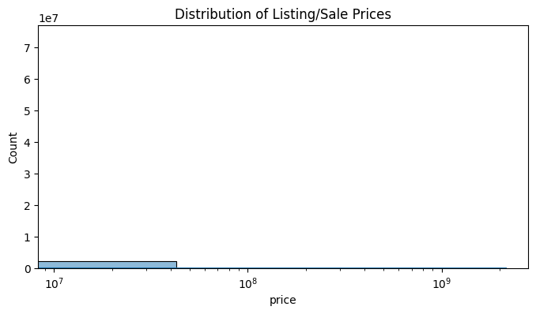

```python
plt.figure(figsize=(8,4))
sns.histplot(df['price'], bins=50, kde=True)
plt.xscale('log')
plt.title("Distribution of Listing/Sale Prices")
file_name = 'price_distribution.png'

plt.savefig(file_name, dpi=300, bbox_inches='tight')
plt.show()
```

### 1.3 Relationship Investigation:

- Examine correlations and interactions between features (e.g., the relationship between `price` and `house size`) to inform model assumptions.

#### 1.3.1 Correlation matrix

*To see, for example, how strongly price correlates with house_size vs. lot size vs. bedrooms.*

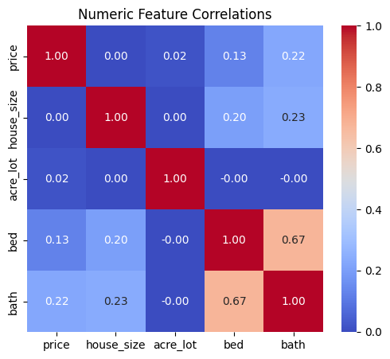

```python
corr = df[num_cols].corr()
plt.figure(figsize=(6,5))
sns.heatmap(corr, annot=True, cmap='coolwarm', fmt=".2f")
plt.title("Numeric Feature Correlations")
plt.show()
```

#### 1.3.2 Scatter plot: price vs. house size

*Sampling 400 K points gives a cloud without flooding the screen—we can see the trend and any weird outliers.*

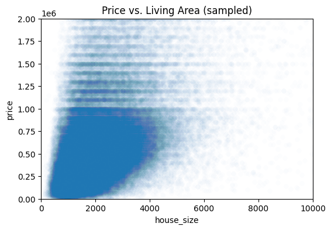

```python
plt.figure(figsize=(6,4))
sns.scatterplot(x='house_size', y='price', data=df.sample(400_000), alpha=0.01)
plt.xlim(0, 10000)
plt.ylim(0, 2e6)
plt.title("Price vs. Living Area (sampled)")
plt.show()
```

### 1.4 Outlier Detection:

- Locate data points that deviate significantly from the majority of the data. This prevents skewing results during model training.

#### 1.4.1 Using IQR for price

*The classic “1.5 × IQR” test flags extremely low or high prices we might want to drop or inspect individually.*

```python
q1, q3 = df['price'].quantile([0.25,0.75])
iqr = q3 - q1
lower, upper = q1 - 1.5*iqr, q3 + 1.5*iqr

outliers = df[(df['price'] < lower) | (df['price'] > upper)]
print(f"Number of price‐outliers: {len(outliers)}")
```

```
Number of price‐outliers: 171600
```

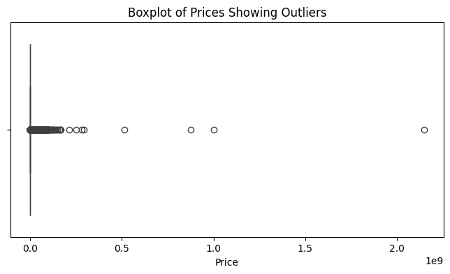

```python
plt.figure(figsize=(8, 4))
sns.boxplot(x=df['price'])
plt.title("Boxplot of Prices Showing Outliers")
plt.xlabel("Price")
plt.show()
```

When there’s a huge outlier, like a $2 billion listing, it stretches the x-axis, making the rest of the data look squished near zero.  
To fix this issue, we can draw the log of price to compress wide ranges into a viewable scale

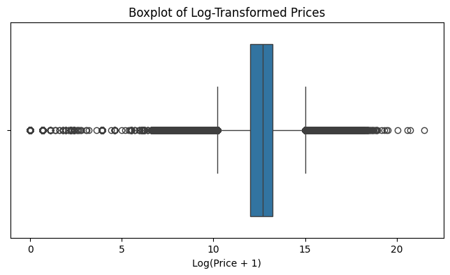

```python
plt.figure(figsize=(8, 4))
sns.boxplot(x=np.log1p(df['price']))  # log1p avoids log(0) by computing log(1 + x)
plt.title("Boxplot of Log-Transformed Prices")
plt.xlabel("Log(Price + 1)")
plt.show()
```

### 1.5 Geospatial and Temporal Insights:

#### 1.5.1 Geospatial:

- Understand the geographic distribution of listings (using fields like `city`, `state`, and `zip code`) and detect natural clusters.

*This code counts the number of listings for each state in the DataFrame and then creates a bar plot to visualize these counts.*

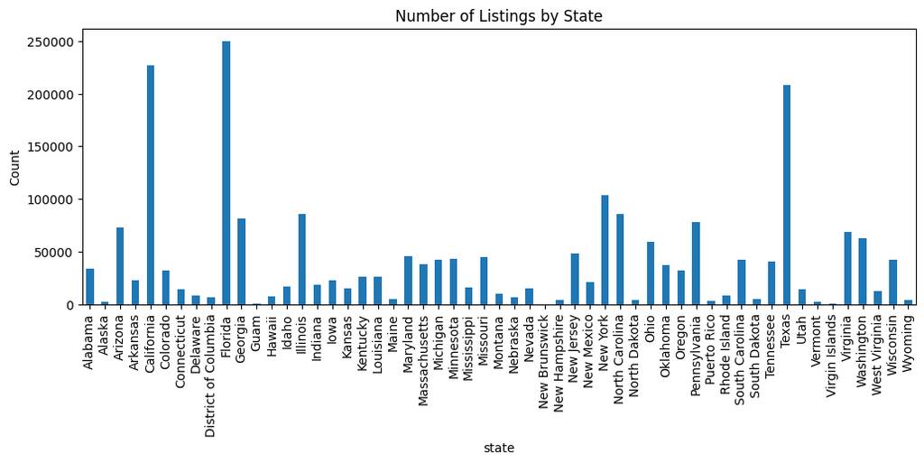

```python
state_counts = df['state'].value_counts().sort_index()
plt.figure(figsize=(12,4))
state_counts.plot(kind='bar')
plt.title("Number of Listings by State")
plt.ylabel("Count")
plt.show()
```

#### 1.5.2 Temporal:

- Identify trends over time (e.g., changes in listing prices over months or seasons) by analyzing dates such as `prev_sold_date`.

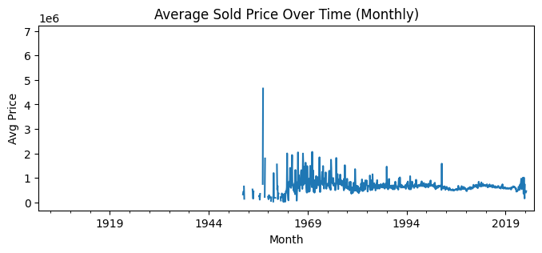

```python
monthly = (
    df
    .dropna(subset=['prev_sold_date'])
    .set_index('prev_sold_date')
    .resample('ME')['price']
    .mean()
)

plt.figure(figsize=(8,3))
monthly.plot()
plt.title("Average Sold Price Over Time (Monthly)")
plt.xlabel("Month")
plt.ylabel("Avg Price")
plt.show()
```

We can see the fluctuations and overall trend during the period from the late 1950s/early 1960s up to the end of the data's collection period.  
There's an initial period of high volatility and a spike, followed by a period of lower, but still fluctuating, average prices.

## 2. Data Preprocessing

Based on the Data Exploration Phase, the following key issues and characteristics were identified:

### Missing Data:

Significant missing values exist in crucial columns like `prev_sold_date`, `house_size`, `bath`, `bed`, and `acre_lot`. Minor missingness is present in `location` (`street`, `city`, `zip_code`, `state`), `brokered_by`, and `price`.

### Outliers and Skewness:

`price`, `house_size`, and `acre_lot` exhibit extreme right-skewness and significant outliers, including potentially erroneous maximum values and zero values (`price`).

### Invalid Data Entries:

`bed` and `bath` columns contain implausible negative minimum values and excessively high maximum values, indicating data entry errors. The minimum `price` of 0 might also be invalid depending on context.

### Categorical Features:

Several features are categorical (`brokered_by`, `status`, `street`, `city`, `state`, `zip_code`) and will require encoding for most machine learning models. `street` has high cardinality.

### Temporal Aspects:

`prev_sold_date` analysis shows long-term trends but is hampered by missing data.

## Preprocessing Steps:

Here’s a detailed manual outlining the recommended preprocessing steps:

We first make a copy of the data frame, to make sure the origianl data frame stays intact.

```python
df_raw   = df
df_clean = df_raw.copy()
```

### 2.1 Initial Cleaning and Data Correction

#### 2.1.1 Handle Invalid bed and bath Values:

Issue: Negative values (e.g., -120, -99) and unrealistically high values (e.g., 123) identified in `bed` and `bath`.

```python
min_allowed, max_allowed = 0, 20

print('We check the number of the [bed, bath] null values before and after convertion of extreme values to null.')
print('Before Conversion:')
print(df_clean[['bed','bath']].isna().sum())


for col in ['bed', 'bath']:
    mask = (df_clean[col] < min_allowed) | (df_clean[col] > max_allowed)
    df_clean.loc[mask, col] = pd.NA

print('After Conversion:')
print(df_clean[['bed','bath']].isna().sum())
```

```
We check the number of the [bed, bath] null values before and after convertion of extreme values to null.
Before Conversion:
bed     481317
bath    511771
dtype: int64
After Conversion:
bed     482042
bath    512172
dtype: int64
```

#### 2.1.2 Address Zero/Low price Values:

Issue: Minimum price is 0.0 identified in the `price` column during data exploration.

We will inspect how many 0 or < $1,000 listings we have

```python
zeroPrice = (df_clean['price'] == 0)
lowPrice  = (df_clean['price'] > 0) & (df_clean['price'] < 1_000)

zero_count = zeroPrice.sum()
low_count  = lowPrice.sum()

print(f"Zero‑price listings: {zero_count}")
print(f"Low‑price (<$1,000) listings: {low_count}")
```

```
Zero‑price listings: 280
Low‑price (<$1,000) listings: 946
```

We peek at a sample to decide if they truly look erroneous:

```python
print("Sample zero‑price listings:")
display(df_clean.loc[zeroPrice].sample(10))

print("\nSample low‑price (<$1,000) listings:")
display(df_clean.loc[lowPrice].sample(10))
```

```
Sample zero‑price listings:
```

|  | brokered_by | status | price | bed | bath | acre_lot | street | city | state | zip_code | house_size | prev_sold_date |
| --- | --- | --- | --- | --- | --- | --- | --- | --- | --- | --- | --- | --- |
| 116304 | 67937.0 | for_sale | 0.0 | <NA> | 1 | NaN | 1089831.0 | Queens | New York | 11101 | NaN | 2021-08-31 |
| 1075770 | 63715.0 | ready_to_build | 0.0 | 3 | <NA> | NaN | 790015.0 | Richmond | Texas | 77406 | 1477.0 | NaT |
| 1119025 | 13859.0 | ready_to_build | 0.0 | 3 | <NA> | NaN | 46746.0 | Bastrop | Texas | 78602 | 1450.0 | NaT |
| 1016922 | 4947.0 | ready_to_build | 0.0 | 4 | <NA> | NaN | 1921905.0 | Celina | Texas | 75009 | 3007.0 | NaT |
| 1002317 | 71540.0 | ready_to_build | 0.0 | 3 | <NA> | NaN | 1972686.0 | Reno | Texas | 76020 | 3039.0 | NaT |
| 1215227 | 91026.0 | ready_to_build | 0.0 | 2 | <NA> | NaN | 938740.0 | Peoria | Arizona | 85383 | 2080.0 | NaT |
| 1002318 | 71540.0 | ready_to_build | 0.0 | 4 | <NA> | NaN | 1972686.0 | Reno | Texas | 76020 | 2409.0 | NaT |
| 1075778 | 63715.0 | ready_to_build | 0.0 | 4 | <NA> | NaN | 790015.0 | Richmond | Texas | 77406 | 2012.0 | NaT |
| 1176591 | 46047.0 | ready_to_build | 0.0 | 3 | <NA> | NaN | 1135405.0 | Nampa | Idaho | 83686 | 2007.0 | NaT |
| 1083735 | 63715.0 | ready_to_build | 0.0 | 4 | <NA> | NaN | 996087.0 | Texas City | Texas | 77591 | 2596.0 | NaT |

```
Sample low‑price (<$1,000) listings:
```

|  | brokered_by | status | price | bed | bath | acre_lot | street | city | state | zip_code | house_size | prev_sold_date |
| --- | --- | --- | --- | --- | --- | --- | --- | --- | --- | --- | --- | --- |
| 305547 | 96684.0 | for_sale | 1.0 | 3 | 1 | 0.460000 | 699565.0 | Fayetteville | North Carolina | 28312 | 1150.0 | 2017-04-07 |
| 270933 | 37369.0 | for_sale | 1.0 | <NA> | <NA> | 0.380000 | 57984.0 | Daniels | West Virginia | 25832 | NaN | NaT |
| 1765715 | 52294.0 | sold | 1.0 | 4 | 4 | 122.750000 | 984348.0 | Logan | Ohio | 43138 | 4740.0 | 2022-01-13 |
| 1252320 | 96912.0 | for_sale | 1.0 | 3 | 4 | NaN | 248531.0 | Truckee | California | 96161 | 1843.0 | 2022-04-28 |
| 844027 | 70449.0 | for_sale | 500.0 | <NA> | <NA> | 0.070000 | 1461540.0 | Mandan | North Dakota | 58554 | NaN | NaT |
| 1838937 | 109734.0 | sold | 1.0 | <NA> | <NA> | 160.000000 | 1918560.0 | Danvers | Minnesota | 56231 | NaN | 2022-04-01 |
| 938408 | 33714.0 | for_sale | 850.0 | <NA> | <NA> | 0.280000 | NaN | Horseshoe Bend | Arkansas | 72512 | NaN | 2022-05-04 |
| 727471 | 55015.0 | for_sale | 1.0 | <NA> | <NA> | 237.000000 | 1673369.0 | Hamlet | Indiana | 46532 | 9999.0 | NaT |
| 832116 | 43412.0 | for_sale | 1.0 | <NA> | <NA> | 72.839996 | 8420.0 | Madelia | Minnesota | 56062 | NaN | NaT |
| 853088 | 77505.0 | for_sale | 50.0 | 2 | 2 | NaN | 132338.0 | Columbia Falls | Montana | 59912 | 1360.0 | NaT |

```python
print("\nBefore cleaning:")
print("  Missing price count:", df_clean['price'].isna().sum())

df_clean['price'] = df_clean['price'].astype('Float64')

df_clean.loc[zeroPrice | lowPrice, 'price'] = pd.NA


print("\nAfter cleaning:")
print("  Missing price count:", df_clean['price'].isna().sum())
```

```
Before cleaning:
  Missing price count: 1541

After cleaning:
  Missing price count: 2767
```

#### 2.1.3 Review `house_size` and `acre_lot` Minimums/Maximums

Issue: Extremely low (`house_size` min 4.0) and high values identified.

- Explore the min/max and distribution.

```python
print("house_size range:", df_clean['house_size'].min(), "to", df_clean['house_size'].max())
print("acre_lot range:", df_clean['acre_lot'].min(), "to", df_clean['acre_lot'].max())

display(df_clean.sort_values('house_size').head(10)[['house_size', 'city', 'state']])
display(df_clean.sort_values('house_size', ascending=False).head(10)[['house_size', 'city', 'state']])


display(df_clean.sort_values('acre_lot').head(10)[['acre_lot', 'city', 'state']])
display(df_clean.sort_values('acre_lot', ascending=False).head(10)[['acre_lot', 'city', 'state']])
```

```
house_size range: 4.0 to 1040400400.0
acre_lot range: 0.0 to 100000.0
```

|  | house_size | city | state |
| --- | --- | --- | --- |
| 129837 | 4.0 | Laurel | New York |
| 1525137 | 100.0 | Chester | Pennsylvania |
| 1278851 | 100.0 | Fontana | California |
| 1278848 | 100.0 | Fontana | California |
| 634521 | 100.0 | Blytheville | Arkansas |
| 2107825 | 100.0 | Big Bear | California |
| 1296520 | 100.0 | Big Bear Lake | California |
| 178317 | 100.0 | Newport | Pennsylvania |
| 1644415 | 100.0 | Atlanta | Georgia |
| 1300953 | 100.0 | Moreno Valley | California |

|  | house_size | city | state |
| --- | --- | --- | --- |
| 1213684 | 1.040400e+09 | Tacna | Arizona |
| 1406699 | 1.299220e+07 | Warden | Washington |
| 434026 | 9.842382e+06 | Pierson | Florida |
| 1127005 | 7.971480e+06 | Rocksprings | Texas |
| 1406177 | 3.484800e+06 | Wenatchee | Washington |
| 1106095 | 3.434706e+06 | Floresville | Texas |
| 204748 | 1.560780e+06 | Philadelphia | Pennsylvania |
| 1126846 | 1.454468e+06 | Rocksprings | Texas |
| 2254 | 1.450112e+06 | Culebra | Puerto Rico |
| 1095437 | 1.306800e+06 | Castroville | Texas |

|  | acre_lot | city | state |
| --- | --- | --- | --- |
| 1260575 | 0.0 | Pasadena | California |
| 886267 | 0.0 | Chicago | Illinois |
| 2146000 | 0.0 | Mountain House | California |
| 886266 | 0.0 | Chicago | Illinois |
| 886262 | 0.0 | Chicago | Illinois |
| 886259 | 0.0 | Chicago | Illinois |
| 2023736 | 0.0 | Peoria | Arizona |
| 886257 | 0.0 | Chicago | Illinois |
| 2023749 | 0.0 | Sun City | Arizona |
| 2017798 | 0.0 | Fountain Hills | Arizona |

|  | acre_lot | city | state |
| --- | --- | --- | --- |
| 284083 | 100000.0 | Sanford | North Carolina |
| 1630589 | 100000.0 | Evans | Georgia |
| 1303520 | 100000.0 | Anza | California |
| 2084560 | 100000.0 | San Marcos | California |
| 1167180 | 100000.0 | Boulder | Wyoming |
| 925406 | 100000.0 | Carl Junction | Missouri |
| 1483290 | 100000.0 | Fort Edward | New York |
| 1150589 | 100000.0 | Hartsel | Colorado |
| 1483261 | 100000.0 | Hebron | New York |
| 1483250 | 100000.0 | Granville | New York |

- Define reasonable thresholds:

- `house_size`: Likely minimum of 100 sqft, maximum maybe 10,000–15,000 sqft?
- `acre_lot`: Unlikely to be < 0.01 or > 1000 acres for residential listings.

```python
min_house_size = 100
max_house_size = 15000

min_acre_lot = 0.01
max_acre_lot = 1000
```

- Create masks for invalid values

```python
invalid_house_size = (df_clean['house_size'] < min_house_size) | (df_clean['house_size'] > max_house_size)
invalid_acre_lot = (df_clean['acre_lot'] < min_acre_lot) | (df_clean['acre_lot'] > max_acre_lot)
```

- Count and sample invalid values (before cleaning)

```python
print(f"Invalid house_size entries: {invalid_house_size.sum()}")
print(f"Invalid acre_lot entries: {invalid_acre_lot.sum()}")
```

```
Invalid house_size entries: 1531
Invalid acre_lot entries: 3945
```

- Apply the cleaning

```python
df_clean['house_size'] = df_clean['house_size'].astype('Float64')
df_clean['acre_lot'] = df_clean['acre_lot'].astype('Float64')

df_clean.loc[invalid_house_size, 'house_size'] = pd.NA
df_clean.loc[invalid_acre_lot, 'acre_lot'] = pd.NA
```

Explore the min/max and distribution after cleaning.

```python
print("house_size range:", df_clean['house_size'].min(), "to", df_clean['house_size'].max())
print("acre_lot range:", df_clean['acre_lot'].min(), "to", df_clean['acre_lot'].max())
```

```
house_size range: 100.0 to 15000.0
acre_lot range: 0.009999999776482582 to 1000.0
```

### 2.2 Handling Missing Data

To begin handling missing data, we must first identify how many entries are missing in each relevant column. Both NaN and pd.NA are treated as missing in pandas operations like .isna(). Below is a count of missing values across the dataset:

```python
missing_counts = df_clean.isna().sum()
missing_counts = missing_counts[missing_counts > 0].sort_values(ascending=False)
display(missing_counts)
```

```
prev_sold_date    734298
house_size        570015
bath              512172
bed               482042
acre_lot          329534
street             10866
brokered_by         4533
price               2767
city                1407
zip_code             299
state                  8
dtype: int64
```

#### 2.2.1 prev_sold_date (734,298 missing)

Issue:The `prev_sold_date` field has over 734,000 missing values, representing a substantial portion of the dataset. While this may seem like a candidate for removal, the field could still provide valuable signals for recommendation models.

This date may reflect how frequently a property has changed hands, or how recently it was listed again, both of which could be useful for modeling buyer behavior and market dynamics. However, using the raw date itself is not ideal.

Create a Binary Indicator

- Introduce a new boolean column `has_prev_sale` that indicates whether the property has been sold before.

```python
df_clean['has_prev_sale'] = df_clean['prev_sold_date'].notna().astype('boolean')
```

```python
df_clean.columns
```

```
Index(['brokered_by', 'status', 'price', 'bed', 'bath', 'acre_lot', 'street',
       'city', 'state', 'zip_code', 'house_size', 'prev_sold_date',
       'has_prev_sale'],
      dtype='object')
```

Convert to Datetime and Calculate "Days Since Previous Sale"

- Convert the `prev_sold_date` to a datetime object (handling errors) and create a new column showing how many days ago the last sale occurred.

```python
from datetime import datetime

df_clean['prev_sold_date'] = pd.to_datetime(df_clean['prev_sold_date'], errors='coerce')

today = pd.to_datetime('today')
df_clean['days_since_prev_sale'] = (today - df_clean['prev_sold_date']).dt.days
```

```python
df_clean.columns
```

```
Index(['brokered_by', 'status', 'price', 'bed', 'bath', 'acre_lot', 'street',
       'city', 'state', 'zip_code', 'house_size', 'prev_sold_date',
       'has_prev_sale', 'days_since_prev_sale'],
      dtype='object')
```

Create Binned Categories for Recency

- Create a categorized column that labels how recent the last sale was in intuitive groups (e.g., "<6mo", "6-12mo", etc.)

```python
df_clean['sale_recency'] = pd.cut(
    df_clean['days_since_prev_sale'],
    bins=[0, 180, 365, 5*365, 10*365, float('inf')],
    labels=['<6mo', '6-12mo', '1-5yr', '5-10yr', '10+yr']
)
```

Dropping the column `days_since_prev_sale` as it's used just as an intermediate step to generate a binned categorical feature `sale_recency`.

```python
df_clean.drop(columns=['days_since_prev_sale'], inplace=True)
```

Now no need to keep the orignal column `prev_sold_date`, as we have engineered meaningful features from it.

```python
df_clean.drop(columns=['prev_sold_date'], inplace=True)
```

But now we have missing values in the column `sale_recency`.

```python
print(df_clean['sale_recency'].isna().sum())
```

```
734299
```

The cause of the problem that there are rows that has no `prev_sold_date`.  
To solve that we could add a new category like "Never Sold".

```python
df_clean['sale_recency'] = df_clean['sale_recency'].cat.add_categories('Never Sold')
df_clean.loc[df_clean['has_prev_sale'] == False, 'sale_recency'] = 'Never Sold'
```

```python
print(df_clean['sale_recency'].isna().sum())
df_clean.head
```

```
1
```

```
<bound method NDFrame.head of         brokered_by    status     price  bed  bath  acre_lot     street  \
0          103378.0  for_sale  105000.0    3     2      0.12  1962661.0
1           52707.0  for_sale   80000.0    4     2      0.08  1902874.0
2          103379.0  for_sale   67000.0    2     1      0.15  1404990.0
3           31239.0  for_sale  145000.0    4     2       0.1  1947675.0
4           34632.0  for_sale   65000.0    6     2      0.05   331151.0
...             ...       ...       ...  ...   ...       ...        ...
2226377     23009.0      sold  359900.0    4     2      0.33   353094.0
2226378     18208.0      sold  350000.0    3     2       0.1  1062149.0
2226379     76856.0      sold  440000.0    6     3       0.5   405677.0
2226380     53618.0      sold  179900.0    2     1      0.09   761379.0
2226381    108243.0      sold  580000.0    5     3      0.31   307704.0

               city        state zip_code  house_size  has_prev_sale  \
0          Adjuntas  Puerto Rico    00601       920.0          False
```

[output cut: 25 more lines]

#### 2.2.2 house_size (570,015 missing)

`house_size` is a key numerical feature that indicates the property's area.

It has 570,015 missing values, which is a significant portion of the dataset.

Since house size heavily influences price and recommendations, we should not drop these rows outright.

Impute Missing `house_size` Using Group Median

Fill missing `house_size` values based on the median within similar property groups.

We’ll use `bed` and `bath` combinations to group similar properties.

Calculate median `house_size` by (`bed`, `bath`) group

```python
group_medians = df_clean.groupby(['bed', 'bath'])['house_size'].median()
```

Create a function to map medians

```python
def impute_house_size(row):
    if pd.isna(row['house_size']):
        return group_medians.get((row['bed'], row['bath']), np.nan)
    return row['house_size']
```

Apply the imputation

```python
df_clean['house_size'] = df_clean.apply(impute_house_size, axis=1)
```

```python
print("Remaining missing house_size values:", df_clean['house_size'].isna().sum())
```

```
Remaining missing house_size values: 470213
```

We will impute the remaining missing `house_size` values using a tiered approach, from the most specific group to the most general:

- Already done: Median by (`bed`, `bath`)
- Next: Median by just `bed`
- Then: Median by just `bath`
- Then: Median by just `price` range
- Finally: Use the overall median as the last resort

Create additional group medians

```python
bed_medians = df_clean.groupby('bed')['house_size'].median()

bath_medians = df_clean.groupby('bath')['house_size'].median()

overall_median = df_clean['house_size'].median()
```

Impute using bed

```python
def impute_step2(row):
    if pd.isna(row['house_size']):
        return bed_medians.get(row['bed'], np.nan)
    return row['house_size']

df_clean['house_size'] = df_clean.apply(impute_step2, axis=1)
print("Missing after bed-only imputation:", df_clean['house_size'].isna().sum())
```

```
Missing after bed-only imputation: 461705
```

Impute using bath

```python
def impute_step3(row):
    if pd.isna(row['house_size']):
        return bath_medians.get(row['bath'], np.nan)
    return row['house_size']

df_clean['house_size'] = df_clean.apply(impute_step3, axis=1)
print("Missing after bath-only imputation:", df_clean['house_size'].isna().sum())
```

```
Missing after bath-only imputation: 459469
```

Impute using Price Range

- First, bin the prices into categories

```python
price_bins = [0, 100_000, 300_000, 600_000, 1_000_000, float('inf')]
price_labels = ['<100k', '100k-300k', '300k-600k', '600k-1M', '1M+']

df_clean['price_range'] = pd.cut(df_clean['price'], bins=price_bins, labels=price_labels)
```

```python
price_range_medians = df_clean.groupby('price_range', observed=True)['house_size'].mean()
price_range_medians
```

```
price_range
<100k        1239.552017
100k-300k    1513.732029
300k-600k    2016.445889
600k-1M      2479.782635
1M+          3435.159040
Name: house_size, dtype: float64
```

Apply it

```python
def impute_step4(row):
    if pd.isna(row['house_size']):
        return price_range_medians.get(row['price_range'], np.nan)
    return row['house_size']

df_clean['house_size'] = df_clean.apply(impute_step4, axis=1)
print("Missing after price-range imputation:", df_clean['house_size'].isna().sum())
```

```
Missing after price-range imputation: 994
```

```python
missing_counts = df_clean.isna().sum()
missing_counts = missing_counts.sort_values(ascending=False)
display(missing_counts)
```

```
bath             512172
bed              482042
acre_lot         329534
street            10866
brokered_by        4533
price              2767
price_range        2767
city               1407
house_size          994
zip_code            299
state                 8
sale_recency          1
status                0
has_prev_sale         0
dtype: int64
```

#### 2.2.3 bath (512,172 missing)

Issue: The `bath` column indicates the number of bathrooms in each property. It’s a discrete numerical feature with a significant impact on both price and property suitability. With over half a million missing values, simply removing rows would greatly reduce the dataset. Hence, imputation is necessary.

Since the number of bathrooms is closely related to the number of bedrooms and price range, we’ll fill the missing `bath` values with the mode of similar groups.

Calculate group-wise mode of bath using bed and price_range

We identify the most common (mode) number of bathrooms for each combination of `bed` and `price_range`.

```python
bath_modes = (
    df_clean.groupby(['bed', 'price_range'], observed=True)['bath']
    .agg(lambda x: x.mode().iloc[0] if not x.mode().empty else np.nan)
)
```

Create an imputation function for bath

This function checks if the value is missing, and if so, assigns the mode based on the `bed` and `price_range` combination.

```python
def impute_bath_mode(row):
    if pd.isna(row['bath']):
        return bath_modes.get((row['bed'], row['price_range']), np.nan)
    return row['bath']
```

Apply the function to impute missing values

We apply the imputation function row by row using `.apply()`.

```python
df_clean['bath'] = df_clean.apply(impute_bath_mode, axis=1)
```

```python
print("Remaining missing bath values:", df_clean['bath'].isna().sum())
```

```
Remaining missing bath values: 472915
```

For the remaining missing bath values, you can impute based on just bed (ignoring price).

- This will likely fill more rows where price is missing or where combinations were too rare.

```python
bath_by_bed = (
    df_clean.groupby('bed', observed=True)['bath']
    .agg(lambda x: x.mode().iloc[0] if not x.mode().empty else np.nan)
)

def impute_bath_by_bed(row):
    if pd.isna(row['bath']):
        return bath_by_bed.get(row['bed'], np.nan)
    return row['bath']

df_clean['bath'] = df_clean.apply(impute_bath_by_bed, axis=1)

print("Remaining missing bath values:", df_clean['bath'].isna().sum())
```

```
Remaining missing bath values: 472279
```

Impute Missing `bath` Using Mode by `house_size` Range

We hypothesize that house size correlates with the number of bathrooms. We will:

1. Create `house_size_range` bins.
2. Group by `house_size_range` and compute the mode of `bath`.
3. Fill missing values of `bath` accordingly.
- Create house size ranges

```python
df_clean['house_size_range'] = pd.cut(
    df_clean['house_size'],
    bins=[0, 800, 1200, 1800, 2500, 3500, float('inf')],
    labels=['XS', 'S', 'M', 'L', 'XL', 'XXL']
)
```

- Calculate mode of bath for each size range

```python
bath_modes_by_size = (
    df_clean.groupby('house_size_range', observed=True)['bath']
    .agg(lambda x: x.mode().iloc[0] if not x.mode().empty else np.nan)
)
```

- Function to apply mode from house size range

```python
def impute_bath_by_size(row):
    if pd.isna(row['bath']):
        return bath_modes_by_size.get(row['house_size_range'], np.nan)
    return row['bath']
```

- Apply the imputation

```python
df_clean['bath'] = df_clean.apply(impute_bath_by_size, axis=1)
print("Remaining missing bath values:", df_clean['bath'].isna().sum())
```

```
Remaining missing bath values: 994
```

```python
df_clean.columns
```

```
Index(['brokered_by', 'status', 'price', 'bed', 'bath', 'acre_lot', 'street',
       'city', 'state', 'zip_code', 'house_size', 'has_prev_sale',
       'sale_recency', 'price_range', 'house_size_range'],
      dtype='object')
```

```python
df_clean.head(5)
```

|  | brokered_by | status | price | bed | bath | acre_lot | street | city | state | zip_code | house_size | has_prev_sale | sale_recency | price_range | house_size_range |
| --- | --- | --- | --- | --- | --- | --- | --- | --- | --- | --- | --- | --- | --- | --- | --- |
| 0 | 103378.0 | for_sale | 105000.0 | 3 | 2.0 | 0.12 | 1962661.0 | Adjuntas | Puerto Rico | 00601 | 920.0 | False | Never Sold | 100k-300k | S |
| 1 | 52707.0 | for_sale | 80000.0 | 4 | 2.0 | 0.08 | 1902874.0 | Adjuntas | Puerto Rico | 00601 | 1527.0 | False | Never Sold | <100k | M |
| 2 | 103379.0 | for_sale | 67000.0 | 2 | 1.0 | 0.15 | 1404990.0 | Juana Diaz | Puerto Rico | 00795 | 748.0 | False | Never Sold | <100k | XS |
| 3 | 31239.0 | for_sale | 145000.0 | 4 | 2.0 | 0.1 | 1947675.0 | Ponce | Puerto Rico | 00731 | 1800.0 | False | Never Sold | 100k-300k | M |
| 4 | 34632.0 | for_sale | 65000.0 | 6 | 2.0 | 0.05 | 331151.0 | Mayaguez | Puerto Rico | 00680 | 2400.0 | False | Never Sold | <100k | L |

```python
missing_counts = df_clean.isna().sum()
missing_counts = missing_counts.sort_values(ascending=False)
display(missing_counts)
```

```
bed                 482042
acre_lot            329534
street               10866
brokered_by           4533
price                 2767
price_range           2767
city                  1407
bath                   994
house_size             994
house_size_range       994
zip_code               299
state                    8
sale_recency             1
status                   0
has_prev_sale            0
dtype: int64
```

#### 2.2.4 bed (482,042 missing)

Issue: The `bed` column represents the number of bedrooms in a property, which is a fundamental feature in real estate datasets. As a discrete numerical value, it significantly impacts a house’s value and livability. With nearly half a million missing entries, deleting rows is not an option. Imputation is necessary to retain as much data as possible.

Since the number of bedrooms often correlates with both house size and price range, we will fill missing values using the mode within logical groupings.

Calculate group-wise mode of `bed` using `house_size_range` and `price_range`

We assume that houses within similar size and price ranges tend to have similar bedroom counts. Thus, we compute the most frequent (mode) value for each combination.

```python
bed_modes = (
    df_clean.groupby(['house_size_range', 'price_range'], observed=True)['bed']
    .agg(lambda x: x.mode().iloc[0] if not x.mode().empty else np.nan)
)
```

Create an imputation function for `bed`

This function looks for a match in the mode table based on the house’s size and price range.

```python
def impute_bed_mode(row):
    if pd.isna(row['bed']):
        return bed_modes.get((row['house_size_range'], row['price_range']), np.nan)
    return row['bed']
```

Apply the function to impute missing `bed` values

```python
df_clean['bed'] = df_clean.apply(impute_bed_mode, axis=1)
print("Remaining missing bed values:", df_clean['bed'].isna().sum())
```

```
Remaining missing bed values: 1052
```

Impute remaining missing `bed` values using only `house_size_range`

For rows where price is missing, we relax the grouping and use only house size ranges to fill in the most likely number of bedrooms.

```python
bed_by_size = (
    df_clean.groupby('house_size_range', observed=True)['bed']
    .agg(lambda x: x.mode().iloc[0] if not x.mode().empty else np.nan)
)

def impute_bed_by_size(row):
    if pd.isna(row['bed']):
        return bed_by_size.get(row['house_size_range'], np.nan)
    return row['bed']

df_clean['bed'] = df_clean.apply(impute_bed_by_size, axis=1)
print("Remaining missing bed values:", df_clean['bed'].isna().sum())
```

```
Remaining missing bed values: 994
```

```python
missing_counts = df_clean.isna().sum()
missing_counts = missing_counts.sort_values(ascending=False)
display(missing_counts)
```

```
acre_lot            329534
street               10866
brokered_by           4533
price                 2767
price_range           2767
city                  1407
bed                    994
bath                   994
house_size             994
house_size_range       994
zip_code               299
state                    8
sale_recency             1
status                   0
has_prev_sale            0
dtype: int64
```

#### 2.2.5 acre_lot (329,534 missing)

Issue: The `acre_lot` column represents the lot size of each property in acres. This is a continuous numerical feature, but it is often highly skewed due to a few properties with extremely large lot sizes (e.g., rural or luxury properties). With over 300,000 missing entries, it's essential to impute rather than drop them to retain valuable data.

Because of the skewed distribution, using the median is more robust than the mean for imputation. The median is less sensitive to outliers and better reflects the typical lot size within specific groups.

Calculate group-wise median of `acre_lot` using `house_size_range` and `price_range`

We assume that properties within similar house sizes and price brackets are likely to have comparable lot sizes. So we group by these two features to compute the median lot size.

```python
acre_medians = df_clean.groupby(['house_size_range', 'price_range'], observed=True)['acre_lot'].median()
```

Create an imputation function for `acre_lot`

This function looks up the appropriate median from the grouped values and fills it in when the original value is missing.

```python
def impute_acre_lot(row):
    if pd.isna(row['acre_lot']):
        return acre_medians.get((row['house_size_range'], row['price_range']), np.nan)
    return row['acre_lot']
```

Apply the function to impute missing values

```python
df_clean['acre_lot'] = df_clean.apply(impute_acre_lot, axis=1)
print("Remaining missing acre_lot values:", df_clean['acre_lot'].isna().sum())
```

```
Remaining missing acre_lot values: 898
```

Impute remaining missing `acre_lot` values using only `house_size_range`

If the price range is missing, we still try to use house size alone as a predictor of lot size.

```python
acre_by_size = (
    df_clean.groupby('house_size_range', observed=True)['acre_lot']
    .median()
)

def impute_acre_by_size(row):
    if pd.isna(row['acre_lot']):
        return acre_by_size.get(row['house_size_range'], np.nan)
    return row['acre_lot']

df_clean['acre_lot'] = df_clean.apply(impute_acre_by_size, axis=1)
print("Remaining missing acre_lot values:", df_clean['acre_lot'].isna().sum())
```

```
Remaining missing acre_lot values: 55
```

```python
missing_counts = df_clean.isna().sum()
missing_counts = missing_counts.sort_values(ascending=False)
display(missing_counts)
```

```
street              10866
brokered_by          4533
price                2767
price_range          2767
city                 1407
bed                   994
bath                  994
house_size            994
house_size_range      994
zip_code              299
acre_lot               55
state                   8
sale_recency            1
status                  0
has_prev_sale           0
dtype: int64
```

#### Review of Remaining Missing Columns

[output not shown]

#### 2.2.6 street (10,866 missing)

Issue: `street` contains the full address or name of the street. This field is very granular and often contains inconsistent, unique values. It’s rarely useful for predictive modeling unless text parsing is applied.

Given the high number of missing values and limited analytical value, we’ll drop this column entirely.

```python
df_clean = df_clean.drop(columns=['street'])
```

#### 2.2.7 brokered_by (4,533 missing)

Issue: The `brokered_by` column contains the name of the real estate agency or individual responsible for listing the property. While not strictly numerical, it can still carry predictive value and may influence sale price trends.

Since broker data is likely categorical and not deeply tied to home features, we'll impute missing values with the string `"Unknown"` to retain the rows while acknowledging absence of this metadata.

```python
print(df_clean['brokered_by'].cat.categories)
```

```
Index(['0.0', '1.0', '10.0', '100.0', '1000.0', '10000.0', '100000.0',
       '100001.0', '100002.0', '100003.0',
       ...
       '99990.0', '99991.0', '99992.0', '99993.0', '99994.0', '99995.0',
       '99996.0', '99997.0', '99998.0', '99999.0'],
      dtype='object', length=110143)
```

```python
df_clean['brokered_by'] = df_clean['brokered_by'].cat.add_categories('Unknown')
```

```python
df_clean['brokered_by'] = df_clean['brokered_by'].fillna('Unknown')
```

#### 2.2.8 price (2,767 missing)

Issue: `price` is one of the most important target variables in real estate datasets. Missing values are likely due to unavailable listings or withheld information.

Since this is a key outcome variable and not predictable with high accuracy for imputation, we'll drop the rows with missing prices.

```python
df_clean = df_clean.dropna(subset=['price'])
```

#### 2.2.9 price_range (2,767 missing)

Issue: `price_range` is a derived categorical column from `price`. The missing values here overlap with the same rows missing `price`.

Therefore, we have already addressed this by dropping rows with missing `price`.

#### 2.2.10 city (1,407 missing)

Issue: The `city` field holds categorical geographic information. This can be critical for modeling location-based property trends. Removing over 1,400 rows would be a significant loss, so imputation is necessary.

Since `city` is strongly associated with `zip_code` and `state`, we’ll impute missing values by assigning the most frequent (mode) city for each combination of `zip_code` and `state`.

Calculate group-wise mode of city using zip_code and state

We group the data by `zip_code` and `state` and compute the most common city in each group.

```python
city_modes = (
    df_clean.groupby(['zip_code', 'state'], observed=True)['city']
    .agg(lambda x: x.mode().iloc[0] if not x.mode().empty else np.nan)
)
```

Create an imputation function for city

This function returns the mode city based on the `zip_code` and `state` combination. If the value is not missing, it returns the existing value.

```python
def impute_city_mode(row):
    if pd.isna(row['city']):
        return city_modes.get((row['zip_code'], row['state']), np.nan)
    return row['city']
```

Apply the function to impute missing values

We apply the imputation function row by row using `.apply()`.

```python
df_clean['city'] = df_clean.apply(impute_city_mode, axis=1)

print("Remaining missing city values:", df_clean['city'].isna().sum())
```

```
Remaining missing city values: 161
```

Fallback imputation based on state only

For the remaining missing values (in case `zip_code` is missing or combination is rare), we use the mode city for each state.

```python
city_by_state = (
    df_clean.groupby('state', observed=True)['city']
    .agg(lambda x: x.mode().iloc[0] if not x.mode().empty else np.nan)
)

def impute_city_by_state(row):
    if pd.isna(row['city']):
        return city_by_state.get(row['state'], np.nan)
    return row['city']

df_clean['city'] = df_clean.apply(impute_city_by_state, axis=1)

print("Remaining missing city values:", df_clean['city'].isna().sum())
```

```
Remaining missing city values: 0
```

#### 2.2.11 zip_code (299 missing)

Issue: `zip_code` is a key geographical identifier, useful for clustering, mapping, or external data merging. Dropping missing entries would result in minor loss, but we can impute more intelligently.

We’ll use group-based mode imputation based on `state` and `city` combinations.

Calculate mode of `zip_code` by state and city:

```python
zip_modes = (
    df_clean.groupby(['state', 'city'], observed=True)['zip_code']
    .agg(lambda x: x.mode().iloc[0] if not x.mode().empty else np.nan)
)
```

Define imputation function:

```python
def impute_zip(row):
    if pd.isna(row['zip_code']):
        return zip_modes.get((row['state'], row['city']), np.nan)
    return row['zip_code']
```

Apply the function

```python
df_clean['zip_code'] = df_clean.apply(impute_zip, axis=1)
```

```python
print("Remaining missing zip_code values:", df_clean['zip_code'].isna().sum())
```

```
Remaining missing zip_code values: 25
```

Fallback – Impute using only city

For the remaining missing values (where `state` is missing or rare combinations exist), we fallback to imputing the most common `zip_code` for each `city` alone.

```python
zip_by_city = (
    df_clean.groupby('city', observed=True)['zip_code']
    .agg(lambda x: x.mode().iloc[0] if not x.mode().empty else np.nan)
)

def impute_zip_by_city(row):
    if pd.isna(row['zip_code']):
        return zip_by_city.get(row['city'], np.nan)
    return row['zip_code']

df_clean['zip_code'] = df_clean.apply(impute_zip_by_city, axis=1)
print("Remaining missing zip_code values:", df_clean['zip_code'].isna().sum())
```

```
Remaining missing zip_code values: 23
```

Final Step: Drop rows with missing `zip_code`

After performing imputation using both (`state`, `city`) and `city` alone, `zip_code` still contains 23 missing values. Since this number is small and `zip_code` is essential for location-based analysis, we choose to drop these rows.

```python
df_clean = df_clean[df_clean['zip_code'].notna()]
```

This ensures a cleaner dataset without compromising too much data, as the remaining missing cases are few and likely difficult to impute reliably.

```python
print("Remaining missing zip_code values:", df_clean['zip_code'].isna().sum())
```

```
Remaining missing zip_code values: 0
```

```python
missing_counts = df_clean.isna().sum()
missing_counts = missing_counts.sort_values(ascending=False)
display(missing_counts)
```

```
state               6
sale_recency        1
brokered_by         0
status              0
price               0
bed                 0
bath                0
acre_lot            0
city                0
zip_code            0
house_size          0
has_prev_sale       0
price_range         0
house_size_range    0
dtype: int64
```

#### 2.2.11 state (6 missing)

Issue: The `state` column represents the U.S. state of the property. It is an essential geographical feature.  
With only 6 missing values, the impact of dropping them is minimal. However, we will first consider imputation.

Imputation using zip_code or city

Both `zip_code` and `city` typically map uniquely to a state. We can attempt to impute the missing `state` based on the most common state for each `zip_code`.

```python
state_by_zip = (
    df_clean.groupby('zip_code', observed=True)['state']
    .agg(lambda x: x.mode().iloc[0] if not x.mode().empty else np.nan)
)

def impute_state_from_zip(row):
    if pd.isna(row['state']):
        return state_by_zip.get(row['zip_code'], np.nan)
    return row['state']

df_clean['state'] = df_clean.apply(impute_state_from_zip, axis=1)
print("Remaining missing state values:", df_clean['state'].isna().sum())
```

```
Remaining missing state values: 6
```

Fallback using city (as zip_code is not useful)

```python
state_by_city = (
    df_clean.groupby('city', observed=True)['state']
    .agg(lambda x: x.mode().iloc[0] if not x.mode().empty else np.nan)
)

def impute_state_from_city(row):
    if pd.isna(row['state']):
        return state_by_city.get(row['city'], np.nan)
    return row['state']

df_clean['state'] = df_clean.apply(impute_state_from_city, axis=1)
print("Remaining missing state values:", df_clean['state'].isna().sum())
```

```
Remaining missing state values: 6
```

After both imputations, 6 rows still lack a valid `state`. To ensure consistency and avoid downstream issues, we drop them:

```python
df_clean = df_clean[df_clean['state'].notna()]
```

#### 2.2.12 sale_recency (1 missing)

Issue: The `sale_recency` column indicates how recently the property was sold.

Since only one value is missing, we simply use the most frequent category.

```python
mode_sale_recency = df_clean['sale_recency'].mode()[0]
df_clean['sale_recency'] = df_clean['sale_recency'].fillna(mode_sale_recency)
print("Remaining missing sale_recency values:", df_clean['sale_recency'].isna().sum())
```

```
Remaining missing sale_recency values: 0
```

```python
missing_counts = df_clean.isna().sum()
missing_counts = missing_counts.sort_values(ascending=False)
display(missing_counts)
```

```
brokered_by         0
status              0
price               0
bed                 0
bath                0
acre_lot            0
city                0
state               0
zip_code            0
house_size          0
has_prev_sale       0
sale_recency        0
price_range         0
house_size_range    0
dtype: int64
```

```python
df_clean.info()
```

```
<class 'pandas.core.frame.DataFrame'>
Index: 2223586 entries, 0 to 2226381
Data columns (total 14 columns):
 #   Column            Dtype
---  ------            -----
 0   brokered_by       category
 1   status            category
 2   price             Float64
 3   bed               float64
 4   bath              float64
 5   acre_lot          float64
 6   city              object
 7   state             object
 8   zip_code          object
 9   house_size        float64
 10  has_prev_sale     boolean
 11  sale_recency      category
 12  price_range       category
 13  house_size_range  category
dtypes: Float64(1), boolean(1), category(5), float64(4), object(3)
memory usage: 180.9+ MB
```

**Exporting Sample of clean_data beforeTransformation**

```python
import pandas as pd



output_filename = 'realtor_data_sample_10k.csv'

sample_size = 10000

print(f"Sampling {sample_size} rows...")
df_10k_sample = df_clean.sample(n=sample_size, random_state=42)
print(f"Successfully sampled {len(df_100k_sample)} rows.")

print(f"Saving 10k sample to: {output_filename}")
df_10k_sample.to_csv(output_filename, index=False)
print(f"Successfully saved the 10k sample.")
```

[output not shown]

```python
df_10k_sample.head()
```

|  | brokered_by | status | price | bed | bath | acre_lot | city | state | zip_code | house_size | has_prev_sale | sale_recency | price_range | house_size_range |
| --- | --- | --- | --- | --- | --- | --- | --- | --- | --- | --- | --- | --- | --- | --- |
| 1489003 | 56507.0 | sold | 210000.0 | 3.0 | 1.0 | 0.180000 | Amherst | New York | 14226 | 1230.000000 | True | 1-5yr | 100k-300k | M |
| 172048 | 53138.0 | for_sale | 299900.0 | 4.0 | 2.0 | 9.000000 | Cumberland | Maryland | 21502 | 2663.000000 | False | Never Sold | 100k-300k | XL |
| 2041823 | 22416.0 | sold | 425000.0 | 3.0 | 2.0 | 0.100000 | Albuquerque | New Mexico | 87111 | 2079.000000 | True | 1-5yr | 300k-600k | L |
| 2168945 | 17327.0 | sold | 1175000.0 | 2.0 | 2.0 | 16.959999 | Woodland | California | 95695 | 1604.000000 | True | 1-5yr | 1M+ | M |
| 1727605 | 31712.0 | sold | 49900.0 | 3.0 | 2.0 | 0.190000 | Lakeland | Florida | 33805 | 1239.552017 | True | 1-5yr | <100k | M |

```python
df_10k_sample.columns
```

```
Index(['brokered_by', 'status', 'price', 'bed', 'bath', 'acre_lot', 'city',
       'state', 'zip_code', 'house_size', 'has_prev_sale', 'sale_recency',
       'price_range', 'house_size_range'],
      dtype='object')
```

### 2.3 Feature Transformation and Encoding

#### 2.3.1 Log Transform Skewed Numerical Features

Before applying log transformations, we need to identify the numerical features and check for skewness.

From `df_clean.info()`, the relevant numerical columns are:

- `price` (Float64)
- `bed` (float64)
- `bath` (float64)
- `acre_lot` (float64)
- `house_size` (float64)

Let’s isolate them and inspect the distribution and skewness.

Check for Skewness

```python
numerical_cols = ['price', 'bed', 'bath', 'acre_lot', 'house_size']

skewness = df_clean[numerical_cols].skew().sort_values(ascending=False)
print("Skewness of numerical features:\n", skewness)
```

[output not shown]

```python
skewed_features = ['price', 'acre_lot', 'house_size', 'bath', 'bed']

for col in skewed_features:
    df_clean[f'{col}_log'] = np.log1p(df_clean[col])
log_cols = [f'{col}_log' for col in numerical_cols]
a_skewness = df_clean[log_cols].skew().sort_values(ascending=False)
print("Skewness of numerical features after log transform:\n", a_skewness)
```

[output not shown]

We will try several additional transformations on `acre_lot_log` to see which one most efficiently reduces its remaining skewness. These transformations include square root, cube root, inverse, and power transformations. We will then compare the skewness values and select the best transformation based on the closest result to normal distribution (i.e., skewness near 0).

- Trying square root transformation

```python
df_clean['acre_lot_sqrt'] = np.sqrt(df_clean['acre_lot_log'])
print("Skewness (sqrt):", df_clean['acre_lot_sqrt'].skew())
```

[output not shown]

- Trying cube root transformation

```python
df_clean['acre_lot_cbrt'] = np.cbrt(df_clean['acre_lot_log'])
print("Skewness (cube root):", df_clean['acre_lot_cbrt'].skew())
```

[output not shown]

- Trying inverse transformation

```python
df_clean['acre_lot_inv'] = 1 / (df_clean['acre_lot_log'] + 1)  # avoid division by zero
print("Skewness (inverse):", df_clean['acre_lot_inv'].skew())
```

[output not shown]

- Trying power transformation (raising to power of 2)

```python
df_clean['acre_lot_pow2'] = df_clean['acre_lot_log'] ** 2
print("Skewness (power 2):", df_clean['acre_lot_pow2'].skew())
```

[output not shown]

- Trying Box-Cox transformation (only works on positive values)

```python
from scipy.stats import boxcox

acre_lot_log_pos = df_clean['acre_lot_log'] + 1
df_clean['acre_lot_boxcox'], _ = boxcox(acre_lot_log_pos)
print("Skewness (box-cox):", pd.Series(df_clean['acre_lot_boxcox']).skew())
```

[output not shown]

Skewness (Box-Cox): 0.5186

Therefore, we will retain the `acre_lot_boxcox` feature for use in further analysis and modeling.

```python
df_clean.columns
```

We’ll do the following:

- Store the original numerical columns in case we need them later.
- Overwrite the original columns (`price`, `bed`, `bath`, `acre_lot`, `house_size`) with their respective best-transformed values:
  - `price_log` → `price`
  - `bed_log` → `bed`
  - `bath_log` → `bath`
  - `house_size_log` → `house_size`
  - `acre_lot_boxcox` → `acre_lot`
- Drop all other intermediate transformation columns.

```python
original_numerical_values = df_clean[['price', 'bed', 'bath', 'acre_lot', 'house_size']].copy()

df_clean['price'] = df_clean['price_log']
df_clean['bed'] = df_clean['bed_log']
df_clean['bath'] = df_clean['bath_log']
df_clean['house_size'] = df_clean['house_size_log']
df_clean['acre_lot'] = df_clean['acre_lot_boxcox']

columns_to_drop = [
    'price_log', 'acre_lot_log', 'house_size_log', 'bath_log', 'bed_log',
    'acre_lot_sqrt', 'acre_lot_cbrt', 'acre_lot_inv', 'acre_lot_pow2', 'acre_lot_boxcox'
]
df_clean.drop(columns=columns_to_drop, inplace=True)
```

```python
df_clean.columns
```

#### 2.3.2 Outlier Treatment (Post-Transformation)

Issue: Even after applying log and Box-Cox transformations to reduce skewness, some extreme values may still persist in the data. These outliers can distort statistical summaries and model training, especially in algorithms sensitive to range and variance.

To ensure the dataset is balanced and robust for modeling, we will visually and statistically inspect the transformed numerical columns for remaining outliers. Outlier treatment can help improve the performance and reliability of models, especially when outliers are due to data entry errors, rare events, or represent non-informative anomalies.

Visual inspection using boxplots and histograms for each transformed numerical column

Use the Interquartile Range (IQR) method to statistically identify outliers

Apply winsorization or capping for mild outliers, or trimming for extreme values, depending on their nature and domain logic

Review the impact of treatment on data distribution and confirm no important data characteristics are lost

Visual inspection using boxplots and histograms for each transformed numerical column

```python
plt.figure(figsize=(15, 10))
for i, col in enumerate(numerical_cols, 1):
    plt.subplot(2, 3, i)
    sns.boxplot(data=df_clean, x=col, color='lightblue')
    plt.title(f'Boxplot of {col}')
plt.tight_layout()
plt.show()
```

[output not shown]

Use the Interquartile Range (IQR) method to statistically identify outliers

```python
def iqr_bounds(series):
    Q1 = series.quantile(0.25)
    Q3 = series.quantile(0.75)
    IQR = Q3 - Q1
    lower_bound = Q1 - 1.5 * IQR
    upper_bound = Q3 + 1.5 * IQR
    return lower_bound, upper_bound

for col in numerical_cols:
    lb, ub = iqr_bounds(df_clean[col])
    outliers = df_clean[(df_clean[col] < lb) | (df_clean[col] > ub)]
    print(f"{col} has {len(outliers)} outliers")
```

[output not shown]

Apply capping (winsorization) to limit extreme values within IQR bounds

```python
def cap_outliers(series):
    Q1 = series.quantile(0.25)
    Q3 = series.quantile(0.75)
    IQR = Q3 - Q1
    lower_bound = Q1 - 1.5 * IQR
    upper_bound = Q3 + 1.5 * IQR
    return series.clip(lower=lower_bound, upper=upper_bound)

columns_to_cap = ['price', 'bed', 'bath', 'house_size']

for col in columns_to_cap:
    df_clean[col] = cap_outliers(df_clean[col])
```

```python
for col in numerical_cols:
    lb, ub = iqr_bounds(df_clean[col])
    outliers = df_clean[(df_clean[col] < lb) | (df_clean[col] > ub)]
    print(f"{col} has {len(outliers)} outliers")
```

[output not shown]

At this point, the numerical features are well-transformed and adjusted for skewness and outliers, setting a strong foundation for modeling.

```python
df.columns
```

```python
df_clean.columns
```

#### 2.3.3 Review of Distribution Changes After Treatment

Objective: To ensure that the transformations and outlier treatments improved skewness and distribution without eliminating meaningful data characteristics or patterns.

After cleaning, each numerical feature was transformed (mostly log or Box-Cox) and capped to handle extreme values. Now, we review the statistical summary and visual distribution to confirm the integrity and effectiveness of those changes.

Review descriptive statistics (mean, std, min, max, skewness) before and after treatment

```python
original_summary = df[['price', 'bed', 'bath', 'acre_lot', 'house_size']].describe().T
original_summary['skewness'] = df[['price', 'bed', 'bath', 'acre_lot', 'house_size']].skew()

cleaned_summary = df_clean[['price', 'bed', 'bath', 'acre_lot', 'house_size']].describe().T
cleaned_summary['skewness'] = df_clean[['price', 'bed', 'bath', 'acre_lot', 'house_size']].skew()

comparison = original_summary[['mean', 'std', 'min', 'max', 'skewness']].join(
    cleaned_summary[['mean', 'std', 'min', 'max', 'skewness']],
    lsuffix='_original', rsuffix='_cleaned'
)

print(comparison)
```

More Reasonable Value Ranges: Originally extreme values such as `price` = 2,147,483,600 or `house_size` = 1,040,400,384 were capped, significantly narrowing the range without erasing genuine high-end variability. The maximum cleaned values now remain within a statistically meaningful boundary (e.g., price max ~15.02 in log scale).

No Distortion of Central Tendencies: The mean values post-cleaning remain within logical ranges that are reflective of the cleaned data distribution, without suggesting data loss. This is particularly important for features like `bed` and `bath`, which maintained sensible averages (e.g., bed mean ~1.41, bath mean ~1.18).

Skewness Insights for Box-Cox: Notably, `acre_lot` was transformed using the Box-Cox method, which resulted in a manageable skewness of 0.52 — a significant reduction from the original 106.28. This shows that Box-Cox effectively normalized a heavily skewed feature while preserving data utility.

#### 2.3.4 Visual Comparison of Numerical Features: Before vs. After Cleaning

Objective: To understand the impact of initial cleaning and data correction, handling missing values, transformations and outlier treatments, we plot the distributions of key numerical features from the original dataset and the cleaned dataset side-by-side.

```python
sns.set(style="whitegrid")
plt.rcParams['figure.figsize'] = (12, 4)

num_features = ['price', 'bed', 'bath', 'acre_lot', 'house_size']

for col in num_features:
    fig, axes = plt.subplots(1, 2, figsize=(14, 4))

    sns.histplot(df[col], bins=50, kde=True, ax=axes[0], color='tomato')
    axes[0].set_title(f"{col} (Original - Before Cleaning)")

    sns.histplot(df_clean[col], bins=50, kde=True, ax=axes[1], color='seagreen')
    axes[1].set_title(f"{col} (After Cleaning)")

    plt.tight_layout()
    plt.show()
```

```python
df_clean.info()
```

#### 2.3.5 Encode Categorical Features

Issue: Several originally categorical location-related features (`city`, `state`, `zip_code`) are now of type `object` instead of `category`. This change could affect the efficiency and consistency of encoding methods like One-Hot or Label Encoding, as `category` dtype is more memory-efficient and faster for such operations.

Why This Happened: The transition from `category` to `object` likely occurred during the preprocessing and cleaning steps, especially those involving:

Handling Missing Values: Operations like `fillna()` or `replace()` can silently upcast a `category` column to `object` if the fill value is not explicitly cast back to a category. For example, filling with `"Unknown"` or `mode()` returns a string/object unless re-casted.

Copying to `df_clean`: If the columns were copied manually or through slicing without preserving the dtype context (especially when selecting columns across DataFrames), dtype reversion to `object` can occur.

Before encoding, we should explicitly restore the original dtypes where needed:

```python
categorical_cols = ['city', 'state', 'zip_code']
df_clean[categorical_cols] = df_clean[categorical_cols].astype('category')
```

```python
df_clean.info()
```

Understanding Categorical Encoding

Issue: Choosing the wrong encoding strategy for a categorical feature can lead to poor model performance, memory issues, or misleading interpretations.

Categorical encoding transforms non-numeric data (like city names or property status) into numerical representations that machine learning models can understand. The choice depends on:

- Cardinality: Number of unique values in a column.
- Feature semantics: Does the feature have an order (ordinal)? Is it nominal (no inherent order)?
- Model requirements: Tree-based models handle numeric values differently than linear models.

##### Types of Encoding Techniques

##### 1. Label Encoding

Assigns a unique integer to each category.

Use When: The categorical variable is ordinal or when using tree-based models.  
Avoid When: The variable is nominal and used in linear models, as it may imply a false order.

##### 2. One-Hot Encoding

Creates a new binary column for each category.

Use When: Cardinality is low and you're using linear models.  
Avoid When: Cardinality is high (can cause feature explosion).

##### 3. Frequency Encoding

Replaces each category with its frequency count.

Use When: The feature has high cardinality and frequency is meaningful.  
Avoid When: Frequencies might mislead the model or bias predictions.

##### 4. Target Encoding

Replaces each category with the average of the target variable for that category.

Use When: The category strongly correlates with the target and you control for overfitting.  
Avoid When: There's a high risk of data leakage without proper cross-validation.

##### 5. Ordinal Encoding

Assigns rank-based numbers to ordered categories.

Use When: The data has an inherent order.  
Avoid When: The categories are nominal (unordered).

**Cardinality Inspection First**

Before choosing an encoding method, inspect the number of unique values in the column:

```python
df_clean.select_dtypes(include='category').nunique()
```

Encoding brokered_by

We will use Frequency Encoding because this column has very high cardinality (110,098 unique values). One-hot encoding would lead to memory inefficiency and dimensional explosion. Frequency encoding keeps the structure compact while preserving some distributional information, which is suitable for tree-based recommendation models.

```python
broker_freq = df_clean['brokered_by'].value_counts(normalize=True)
df_clean['brokered_by_encoded'] = df_clean['brokered_by'].map(broker_freq)
```

Encoding status

We will use One-Hot Encoding because this column has only 3 unique values and represents mutually exclusive categories. One-hot encoding avoids introducing any unintended ordinal relationship and is interpretable.

```python
df_clean = pd.get_dummies(df_clean, columns=['status'], prefix='status', drop_first=False)
```

Encoding city

We will use Frequency Encoding because this column has 20,056 unique values. One-hot encoding is not feasible. Frequency encoding reduces dimensionality while preserving relative occurrence patterns, especially suitable for models that handle numerical features well.

```python
city_freq = df_clean['city'].value_counts(normalize=True)
df_clean['city_encoded'] = df_clean['city'].map(city_freq)
```

Encoding state

We will use Label Encoding because the number of unique states is moderate (55), and the recommendation algorithm may use tree-based models, which handle label-encoded data appropriately without assuming ordinal relationships.

```python
from sklearn.preprocessing import LabelEncoder

le_state = LabelEncoder()
df_clean['state_encoded'] = le_state.fit_transform(df_clean['state'])
```

Encoding zip_code

We will use Frequency Encoding because the number of unique zip codes (30,311) makes one-hot encoding impractical. Frequency encoding allows the model to consider common and rare zip codes differently without high memory cost.

```python
zip_freq = df_clean['zip_code'].value_counts(normalize=True)
df_clean['zip_code_encoded'] = df_clean['zip_code'].map(zip_freq)
```

Encoding sale_recency

We will use Ordinal Encoding because the categories of `sale_recency` represent a meaningful and ordered timeline: from very recent sales to never sold. Preserving this order is essential, as a model that recommends properties may infer different patterns based on how recently a property was sold. Treating these values as purely nominal would discard this structure, potentially degrading model quality.

```python
sale_recency_order = ['<6mo', '6-12mo', '1-5yr', '5-10yr', '10+yr', 'Never Sold']
df_clean['sale_recency'] = df_clean['sale_recency'].cat.set_categories(sale_recency_order, ordered=True).cat.codes
```

```python
df_clean.info()
```

Encoding price_range

We will use One-Hot Encoding because price ranges are non-numerical groupings and do not carry a strict order. One-hot ensures the model does not assume price_range is continuous or ordinal.

```python
df_clean = pd.get_dummies(df_clean, columns=['price_range'], prefix='price_range', drop_first=False)
```

encoding house_size_range

We will use Ordinal Encoding for `house_size_range` because the categories represent an increasing scale of property size—from extra small (XS) to extra extra large (XXL). This order reflects real differences in living space, and preserving this order numerically allows the model to capture size-related trends while still using a single numerical feature instead of multiple binary indicators.

```python
size_order = ['XS', 'S', 'M', 'L', 'XL', 'XXL']
df_clean['house_size_range'] = df_clean['house_size_range'].cat.set_categories(size_order, ordered=True).cat.codes
```

```python
df_clean.info()
```

List of Variables

The categorical columns that were encoded and are candidates for dropping are:

- `brokered_by`
- `status`
- `city`
- `state`
- `zip_code`
- `price_range`
- `house_size_range`
- `sale_recency`

Each of the above columns has been encoded through frequency, label, ordinal, or one-hot encoding. Keeping both original and encoded versions creates unnecessary duplication, increasing memory usage and potentially confusing models that expect numerical input.

Dropping the original columns is a strong and standard approach. It maintains model clarity and dimensional efficiency. Keeping encoded versions supports training while storing the original values in a separate backup preserves interpretability.

Save a copy of original categorical values before dropping

```python
original_categoricals = df_clean[[
    'brokered_by', 'city', 'state',
    'zip_code', 'house_size_range', 'sale_recency'
]].copy()
```

```python
df_clean.info()
```

```python
df_clean.drop(columns=[
    'brokered_by', 'city', 'state',
    'zip_code', 'house_size_range', 'sale_recency'
], inplace=True)
```

```python
df_clean.info()
```

```python
df_clean.sample(10)
```

### 2.4 Scaling

#### 2.4.1 Scale Numerical Features

At this stage, the numerical features in the dataset — such as `price`, `bed`, `bath`, `acre_lot`, `house_size`, and others — differ significantly in magnitude. Some features are already transformed (e.g., using log), but they are still not on the same scale. Algorithms like KNN, SVM, Neural Networks, PCA, and Linear Models are sensitive to feature magnitudes. Hence, scaling is essential to standardize the influence of features during model training.

Variables to Scale

From `df_clean.info()` and sample output, the relevant numerical columns to scale include:

```python
columns_to_scale = [
    'price', 'bed', 'bath', 'acre_lot', 'house_size',
    'brokered_by_encoded', 'city_encoded', 'state_encoded', 'zip_code_encoded'
]
```

Code to Scale (with Saving Original Values)

```python
from sklearn.preprocessing import StandardScaler

df_clean_original = df_clean.copy()

scaler = StandardScaler()

df_clean[columns_to_scale] = scaler.fit_transform(df_clean[columns_to_scale])
```

Why We Applied StandardScaler

`StandardScaler` standardizes features by removing the mean and scaling to unit variance (i.e., each feature will have a mean of 0 and a standard deviation of 1). It’s particularly suited when features are normally distributed or close to symmetric after transformation (e.g., after applying log). It preserves outliers rather than squashing them into a fixed range.

When to Use Each Scaler

| Scaler | Use When | Characteristics |
| --- | --- | --- |
| `StandardScaler` | Most models like linear regression, logistic regression, SVMs, PCA, KNN, and neural networks | Assumes Gaussian-like distribution (even approximately); robust to range issues, but sensitive to outliers |
| `MinMaxScaler` | When preserving zero-bound ranges matters (e.g., image pixel data in [0, 255]) or for algorithms that are not robust to scale variance | Scales values to a fixed [0, 1] range; sensitive to outliers |
| `RobustScaler` | If your data has many outliers and you want to mitigate their influence | Uses median and IQR, making it stable even when extreme values exist |
| `Normalizer` | For text/vector data, when you want to scale individual samples to unit norm | Not for feature-wise scaling, but sample-wise normalization (rare in tabular data) |

Why StandardScaler Specifically Fits Our Case

- Features (`price`, `acre_lot`, `house_size`) were log-transformed to reduce skewness — making them closer to normal distribution, which is ideal for StandardScaler.
- Likely using models that assume or perform better when features are centered and have the same variance (e.g., regression, SVM, PCA).
- Don’t need to preserve a [0,1] range for interpretation or image inputs.

### 2.5 Final Review

#### 2.4.1 Comparing df vs. df_clean

- Shape & Missingness

```python
print("Rows:", df.shape[0], "→", df_clean.shape[0])
print("Cols:", df.shape[1], "→", df_clean.shape[1])
print("\nMissing values (original):\n", df.isnull().sum())
print("\nMissing values (cleaned):\n", df_clean.isnull().sum())
```

```
Rows: 2226382 → 2223586
Cols: 12 → 18

Missing values (original):
 brokered_by         4533
status                 0
price               1541
bed               481317
bath              511771
acre_lot          325589
street             10866
city                1407
state                  8
zip_code             299
house_size        568484
prev_sold_date    734298
dtype: int64

Missing values (cleaned):
 price                    0
bed                      0
bath                     0
acre_lot                 0
house_size               0
has_prev_sale            0
brokered_by_encoded      0
status_for_sale          0
status_ready_to_build    0
status_sold              0
city_encoded             0
state_encoded            0
zip_code_encoded         0
price_range_<100k        0
price_range_100k-300k    0
price_range_300k-600k    0
price_range_600k-1M      0
price_range_1M+          0
dtype: int64
```

- Duplicates & Cardinality

```python
print("\nDuplicates removed:", df.shape[0] - df.drop_duplicates().shape[0])
print("Duplicates now:", df_clean.shape[0] - df_clean.drop_duplicates().shape[0])
for col in ['city', 'state', 'brokered_by']:
    print(f"Unique {col}:",
          df[col].nunique(),
          "→",
          df_clean[f"{col}_encoded"].nunique()
         )
```

```
Duplicates removed: 0
Duplicates now: 62495
Unique city: 20098 → 1129
Unique state: 55 → 55
Unique brokered_by: 110143 → 764
```

- Numeric summaries

```python
print("\nOriginal numeric stats:\n", df.describe().T[['mean','50%','std','min','max']])
print("\nCleaned numeric stats:\n", df_clean.describe().T[['mean','50%','std','min','max']])
```

```
Original numeric stats:
                                          mean                  50%  \
price                           524195.519291             325000.0
bed                                  3.273934                  3.0
bath                                 2.494051                  2.0
acre_lot                            15.223025                 0.26
house_size                        2714.472412               1760.0
prev_sold_date  2017-08-16 04:21:19.095814912  2021-12-01 00:00:00

                           std                  min                  max
price           2138893.221114                  0.0         2147483600.0
bed                   1.419179               -120.0                123.0
bath                  1.315874                -99.0                123.0
acre_lot            762.823792                  0.0             100000.0
house_size         808163.5625                  4.0         1040400384.0
prev_sold_date             NaN  1901-01-01 00:00:00  2026-04-08 00:00:00

Cleaned numeric stats:
                              mean       50%  std       min       max
price               -7.915744e-15  0.115833  1.0 -2.248631  2.335807
bed                  6.533609e-16 -0.155831  1.0 -1.804501  2.591954
bath                 1.233200e-15 -0.338566  1.0 -1.874834  2.386431
acre_lot             4.251907e-16 -0.278401  1.0 -1.869719  1.966507
house_size          -2.748779e-15 -0.161903  1.0 -2.807242  2.725107
brokered_by_encoded -2.106461e-17 -0.250372  1.0 -0.264691  5.902210
city_encoded        -8.860430e-17 -0.381999  1.0 -0.549337  6.001525
state_encoded        5.071868e-17 -0.063053  1.0 -1.493288  1.724740
zip_code_encoded    -8.875769e-17 -0.247041  1.0 -1.044218  8.475695
```

- Distributional tests

```python
from scipy.stats import ks_2samp, chi2_contingency

for col in ['price', 'bed', 'bath', 'acre_lot', 'house_size']:
    stat, p = ks_2samp(df[col].dropna(), df_clean[col].dropna())
    print(f"KS on {col}: stat={stat:.3f}, p‑value={p:.3f}")
```

```
KS on price: stat=1.000, p‑value=0.000
KS on bed: stat=0.939, p‑value=0.000
KS on bath: stat=0.891, p‑value=0.000
KS on acre_lot: stat=0.616, p‑value=0.000
KS on house_size: stat=1.000, p‑value=0.000
```

- Outliers (1.5×IQR rule) count before/after

```python
def outlier_count(series):
    q1, q3 = series.quantile([.25, .75])
    iqr = q3 - q1
    return ((series < q1 - 1.5*iqr) | (series > q3 + 1.5*iqr)).sum()

for col in ['price', 'acre_lot', 'house_size']:
    print(f"{col} outliers:", outlier_count(df[col].dropna()),
          "→", outlier_count(df_clean[col].dropna()))
```

```
price outliers: 171600 → 0
acre_lot outliers: 292418 → 0
house_size outliers: 77850 → 7655
```

```python
print(df_clean.columns.tolist())
```

[output not shown]

```python
print(df.columns.tolist())
```

```
['brokered_by', 'status', 'price', 'bed', 'bath', 'acre_lot', 'street', 'city', 'state', 'zip_code', 'house_size', 'prev_sold_date']
```

### 2.6 Exporting Processed Data

```python
df_clean.to_csv("clean_data.csv", index=False, encoding='utf-8')
```

## 3. Build a Neural Network Content-Based Recommendation System

### 3.1 Prepare the feature matrix

#### 3.1.0 reduce the dataset size

First, we'll reduce the dataset size by taking a random sample of 300,000 properties to make development faster and computationally more feasible.

```python
import os

sample_size = 300000 # Your chosen rational size

sampled_data_filename = 'realtor_data_sample_300k.csv'

if os.path.exists(sampled_data_filename):
    print(f"Sampled data file '{sampled_data_filename}' already exists. Reading from file.")
    df_sample = pd.read_csv(sampled_data_filename)
else:
    print(f"Original dataset size: {len(df_clean)} rows")
    print(f"Taking a random sample of size: {sample_size} rows")
    df_sample = df_clean.sample(n=sample_size, random_state=42)

    print(f"Exporting sampled data to '{sampled_data_filename}'...")
    df_sample.to_csv(sampled_data_filename, index=False) # index=False prevents writing the DataFrame index as a column
    print("Export complete.")

print(f"Working with a dataset of size: {len(df_sample)} rows")
```

```
Sampled data file 'realtor_data_sample_300k.csv' already exists. Reading from file.
Working with a dataset of size: 300000 rows
```

```python
selected_features = [
    'price', 'bed', 'bath', 'acre_lot', 'house_size', 'has_prev_sale', 'brokered_by_encoded', 'status_for_sale', 'status_ready_to_build', 'status_sold', 'city_encoded', 'state_encoded', 'zip_code_encoded', 'price_range_<100k', 'price_range_100k-300k', 'price_range_300k-600k', 'price_range_600k-1M', 'price_range_1M+'
]
```

#### 3.1.1 Convert to numpy array

```python
item_features_matrix = df_sample[selected_features].values
item_features_matrix
```

```
array([[-0.2998955467907582, -0.1558306726777764, -1.8748335115244303,
        ..., False, False, False],
       [0.0393199502241484, 0.9432831700489444, -0.3385662400475825, ...,
        False, False, False],
       [0.3712045093766736, -0.1558306726777764, -0.3385662400475825,
        ..., True, False, False],
       ...,
       [0.0553722179942128, 0.9432831700489444, 0.751432735598931, ...,
        True, False, False],
       [-0.6208309665609413, -0.1558306726777764, -0.3385662400475825,
        ..., False, False, False],
       [-1.97870948699199, -0.1558306726777764, -0.3385662400475825, ...,
        False, False, False]], dtype=object)
```

Before feeding this `item_features_matrix` into a similarity function, it's best practice to ensure it has a unified numerical `dtype` by explicitly casting it. Booleans (`True`/`False`) will automatically convert to 1/0 during this cast.

```python
item_features_matrix = item_features_matrix.astype(np.float64)
```

```python
item_features_matrix.dtype
```

```
dtype('float64')
```

### 3.2 Calculate Item-Item Similarity

This involves:

1. Using a function designed for pairwise distances/similarities, like `sklearn.metrics.pairwise.pairwise_distances_chunked`.
2. Iterating through the `item_features_matrix` in defined `chunk_size` steps.
3. Within each step, computing the cosine similarity between the current chunk and the entire `item_features_matrix`.
4. For each item in the chunk, finding the indices and similarity scores of its Top N most similar counterparts across the full dataset.
5. Storing these Top N results (e.g., as a list of tuples or in a more permanent storage).

#### 3.2.1 Number of similar items to find and store for each item

```python
N_similar = 50
```

#### 3.2.2 Size of chunks to process at a time

```python
chunk_size = 1000
```

#### 3.2.3 Data Structure to Store Results

We'll store the results as a list of tuples: (`source_item_index`, `similar_item_index`, `similarity_score`)

```python
top_n_similarities_list = []
```

```python
print(f"Chunk size: {chunk_size}")
print(f"Finding Top {N_similar} similar items per item.")
```

```
Chunk size: 1000
Finding Top 50 similar items per item.
```

#### 3.2.4 Perform Chunked Similarity Calculation

```python
total_items = item_features_matrix.shape[0]
total_chunks = int(np.ceil(total_items / chunk_size))
print({f'total items': total_items})
print({f'total chunks': total_chunks})
```

```
{'total items': 300000}
{'total chunks': 300}
```

```python
from sklearn.metrics.pairwise import pairwise_distances_chunked
import time

# Assume item_features_matrix is already prepared from the sampled data
# Assume N_similar, chunk_size, total_items, total_chunks are defined

# Define the filename for storing the similarity results
similarity_results_filename = 'item_top_n_similarities_300k.parquet'

# Check if the similarity results file already exists
if os.path.exists(similarity_results_filename):
    print(f"Similarity results file '{similarity_results_filename}' already exists. Reading from file.")
    similarity_df = pd.read_parquet(similarity_results_filename)
    top_n_similarities_list = similarity_df.values.tolist()
    print(f"Loaded {len(top_n_similarities_list)} similarity pairs.")

else:
    print(f"Starting chunked similarity calculation...")
    print(f"Chunk size: {chunk_size}")
    print(f"Finding Top {N_similar} similar items per item.")

    # --- Data Structure to Store Results ---
    top_n_similarities_list = []

    start_time = time.time() # Start timing the process

    # --- Perform Chunked Similarity Calculation ---
    # pairwise_distances_chunked returns an iterator yielding distance matrices for each chunk
    # n_jobs=-1 uses all available CPU cores for computation
    # working_memory sets a soft limit on memory usage per thread in MB (adjust as needed)
    # Use the feature matrix from the sample
    # Adjust the working_memory value based on your M1's RAM
    memory_limit_mb = 1024 # Example: Try setting a soft limit of 1GB per thread

    for i, distances_chunk in enumerate(pairwise_distances_chunked(item_features_matrix, metric='cosine', n_jobs=-1, working_memory=memory_limit_mb)):
        # Convert cosine distances to similarities (1 - distance)
        similarities_chunk = 1 - distances_chunk

        # Get the global indices for the items in the current chunk
        start_index = i * chunk_size
        end_index = min(start_index + chunk_size, total_items)
        current_chunk_indices = np.arange(start_index, end_index)

        # Process each item in the current chunk
        for j, item_similarities in zip(current_chunk_indices, similarities_chunk):
            # item_similarities is a 1D array of similarities between item j and ALL other items

            # Get indices of similar items, sorted by similarity (descending)
            sorted_indices = item_similarities.argsort()[::-1]

            # Exclude the item itself (similarity score of 1.0)
            sorted_indices = sorted_indices[sorted_indices != j]

            # Get the indices and scores of the Top N similar items
            top_n_indices = sorted_indices[:N_similar]
            top_n_scores = item_similarities[top_n_indices]

            # Store the results
            for k in range(N_similar):
                if k < len(top_n_indices):
                     top_n_similarities_list.append((j, top_n_indices[k], top_n_scores[k]))

        # Optional: Print progress
        if (i + 1) % 10 == 0 or (i + 1) == total_chunks:
            elapsed_time = time.time() - start_time
            estimated_total_time = (elapsed_time / (i + 1)) * total_chunks if (i + 1) > 0 else 0
            print(f"Processed chunk {i + 1}/{total_chunks} ({end_index}/{total_items} items). Elapsed: {elapsed_time:.2f}s. Estimated Total: {estimated_total_time:.2f}s")


    end_time = time.time() # End timing
    total_elapsed_time = end_time - start_time

    print(f"\nChunked similarity calculation finished.")
    print(f"Total time taken: {total_elapsed_time:.2f} seconds ({total_elapsed_time/60:.2f} minutes)")
    print(f"Number of similarity pairs stored: {len(top_n_similarities_list)}")

    # --- Export the Similarity Results ---
    print(f"Exporting similarity results to '{similarity_results_filename}'...")
    similarity_df = pd.DataFrame(top_n_similarities_list, columns=['source_item_index', 'similar_item_index', 'similarity_score'])

    try:
        similarity_df.to_parquet(similarity_results_filename, index=False)
        print("Similarity results export complete (Parquet format).")
    except ImportError:
        print("Parquet libraries (pyarrow or fastparquet) not found. Saving to CSV instead.")
        similarity_results_filename_csv = similarity_results_filename.replace('.parquet', '.csv')
        similarity_df.to_csv(similarity_results_filename_csv, index=False)
        print(f"Similarity results export complete (CSV format) to '{similarity_results_filename_csv}'.")
```

```
Starting chunked similarity calculation...
Chunk size: 1000
Finding Top 50 similar items per item.
Processed chunk 10/300 (10000/300000 items). Elapsed: 120.67s. Estimated Total: 3619.95s
Processed chunk 20/300 (20000/300000 items). Elapsed: 241.56s. Estimated Total: 3623.40s
Processed chunk 30/300 (30000/300000 items). Elapsed: 362.36s. Estimated Total: 3623.63s
Processed chunk 40/300 (40000/300000 items). Elapsed: 485.12s. Estimated Total: 3638.37s
Processed chunk 50/300 (50000/300000 items). Elapsed: 608.18s. Estimated Total: 3649.07s
Processed chunk 60/300 (60000/300000 items). Elapsed: 732.96s. Estimated Total: 3664.82s
Processed chunk 70/300 (70000/300000 items). Elapsed: 855.63s. Estimated Total: 3666.97s
Processed chunk 80/300 (80000/300000 items). Elapsed: 978.17s. Estimated Total: 3668.12s
Processed chunk 90/300 (90000/300000 items). Elapsed: 1101.64s. Estimated Total: 3672.13s
Processed chunk 100/300 (100000/300000 items). Elapsed: 1226.64s. Estimated Total: 3679.93s
Processed chunk 110/300 (110000/300000 items). Elapsed: 1350.30s. Estimated Total: 3682.65s
Processed chunk 120/300 (120000/300000 items). Elapsed: 1470.50s. Estimated Total: 3676.24s
Processed chunk 130/300 (130000/300000 items). Elapsed: 1592.47s. Estimated Total: 3674.92s
Processed chunk 140/300 (140000/300000 items). Elapsed: 1713.59s. Estimated Total: 3671.99s
Processed chunk 150/300 (150000/300000 items). Elapsed: 1835.67s. Estimated Total: 3671.35s
Processed chunk 160/300 (160000/300000 items). Elapsed: 1957.05s. Estimated Total: 3669.47s
Processed chunk 170/300 (170000/300000 items). Elapsed: 2080.18s. Estimated Total: 3670.90s
Processed chunk 180/300 (180000/300000 items). Elapsed: 2203.76s. Estimated Total: 3672.93s
Processed chunk 190/300 (190000/300000 items). Elapsed: 2326.42s. Estimated Total: 3673.29s
Processed chunk 200/300 (200000/300000 items). Elapsed: 2448.52s. Estimated Total: 3672.78s
Processed chunk 210/300 (210000/300000 items). Elapsed: 2573.95s. Estimated Total: 3677.07s
Processed chunk 220/300 (220000/300000 items). Elapsed: 2699.43s. Estimated Total: 3681.04s
Processed chunk 230/300 (230000/300000 items). Elapsed: 2842.22s. Estimated Total: 3707.24s
Processed chunk 240/300 (240000/300000 items). Elapsed: 2998.45s. Estimated Total: 3748.06s
Processed chunk 250/300 (250000/300000 items). Elapsed: 3150.31s. Estimated Total: 3780.37s
Processed chunk 260/300 (260000/300000 items). Elapsed: 3288.13s. Estimated Total: 3794.00s
Processed chunk 270/300 (270000/300000 items). Elapsed: 3425.20s. Estimated Total: 3805.78s
Processed chunk 280/300 (280000/300000 items). Elapsed: 3568.13s. Estimated Total: 3823.00s
Processed chunk 290/300 (290000/300000 items). Elapsed: 3706.82s. Estimated Total: 3834.64s
Processed chunk 300/300 (300000/300000 items). Elapsed: 3845.36s. Estimated Total: 3845.36s
Processed chunk 310/300 (300000/300000 items). Elapsed: 3857.06s. Estimated Total: 3732.64s
Processed chunk 320/300 (300000/300000 items). Elapsed: 3870.27s. Estimated Total: 3628.38s
Processed chunk 330/300 (300000/300000 items). Elapsed: 3882.64s. Estimated Total: 3529.67s
Processed chunk 340/300 (300000/300000 items). Elapsed: 3894.22s. Estimated Total: 3436.08s
Processed chunk 350/300 (300000/300000 items). Elapsed: 3906.26s. Estimated Total: 3348.22s
Processed chunk 360/300 (300000/300000 items). Elapsed: 3918.14s. Estimated Total: 3265.12s
Processed chunk 370/300 (300000/300000 items). Elapsed: 3930.14s. Estimated Total: 3186.60s
```

[output cut: 21 more lines]

```
Processed chunk 590/300 (300000/300000 items). Elapsed: 4151.38s. Estimated Total: 2110.87s
Processed chunk 600/300 (300000/300000 items). Elapsed: 4160.41s. Estimated Total: 2080.20s
Processed chunk 610/300 (300000/300000 items). Elapsed: 4169.03s. Estimated Total: 2050.34s
Processed chunk 620/300 (300000/300000 items). Elapsed: 4177.64s. Estimated Total: 2021.44s
Processed chunk 630/300 (300000/300000 items). Elapsed: 4186.71s. Estimated Total: 1993.67s
Processed chunk 640/300 (300000/300000 items). Elapsed: 4195.71s. Estimated Total: 1966.74s
Processed chunk 650/300 (300000/300000 items). Elapsed: 4204.98s. Estimated Total: 1940.76s
Processed chunk 660/300 (300000/300000 items). Elapsed: 4213.62s. Estimated Total: 1915.28s
Processed chunk 670/300 (300000/300000 items). Elapsed: 4222.08s. Estimated Total: 1890.48s

Chunked similarity calculation finished.
Total time taken: 4223.31 seconds (70.39 minutes)
Number of similarity pairs stored: 6705000
Exporting similarity results to 'item_top_n_similarities_300k.parquet'...
Similarity results export complete (Parquet format).
```

#### 3.2.5 Perform Chunked Similarity Calculation (Revised)

**Addressing an Issue from the Initial Approach:**

In the initial execution (as seen in output), the progress printout showed "Processed chunk X/300" where X eventually exceeded 300 (e.g., "Processed chunk 670/300"). This occurred because:

- The `total_chunks` (300) was calculated based on our `chunk_size` = 1000.
- The `pairwise_distances_chunked` function from scikit-learn internally decides its own chunk sizes for processing, influenced by `working_memory` and `n_jobs`, not directly by our `chunk_size` variable. The loop variable `i` in `for i, distances_chunk in enumerate(...)` was counting these internal scikit-learn chunks.
- The logic for determining `current_chunk_indices` using `start_index = i * chunk_size` was flawed. It incorrectly assumed that the i-th chunk yielded by `pairwise_distances_chunked` corresponded to items starting at `i * chunk_size` from the original matrix and that each yielded chunk would contain `chunk_size` items.

This mismatch led to two main problems:

- **Misleading Progress Indication:** The "X/300" was not accurately reflecting the processing of our conceptually defined chunks.
- **Incomplete Similarity Calculation:** More critically, the incorrect indexing for `current_chunk_indices` (which became `j` in the inner loop) meant that we were not correctly mapping the rows of `similarities_chunk` (the similarities for items within the scikit-learn yielded chunk) back to their correct global indices in the `item_features_matrix`. This resulted in the `item_similarity_lookup` dictionary being generated for only a subset of the total items (e.g., 134,100 out of 300,000 source items in the example output).

**The Corrected Approach:**

The revised code below addresses this by:

- Tracking `processed_items_count` to accurately reflect how many items from the `item_features_matrix` have been processed as source items for similarity calculation.
- Correctly determining the `source_item_global_indices` for each chunk yielded by `pairwise_distances_chunked` based on `processed_items_count` and the actual number of items in the yielded chunk (`similarities_chunk.shape[0]`).
- Updating the progress printing to reflect `processed_items_count` against `total_items`.

The code first checks if the similarity results have already been computed and saved to a Parquet file. If so, it loads them to save time. Otherwise, it performs the calculation. This is crucial for long-running processes.

Loading development sample data (300k)

```python
import os
import pandas as pd
import numpy as np

sample_size = 300000
sampled_data_filename = 'realtor_data_sample_300k.csv'

if os.path.exists(sampled_data_filename):
    print(f"Loaded sampled data: {sampled_data_filename}")
    df_sample = pd.read_csv(sampled_data_filename)
else:
    print(f"Sampling df_clean (size: {len(df_clean) if 'df_clean' in locals() else 'not defined'}) to {sample_size} rows.")
    df_sample = df_clean.sample(n=sample_size, random_state=42)
    df_sample.to_csv(sampled_data_filename, index=False)
    print(f"Saved sampled data to: {sampled_data_filename}")

print(f"Working with {len(df_sample)} rows.")

selected_features = [
    'price', 'bed', 'bath', 'acre_lot', 'house_size', 'has_prev_sale',
    'brokered_by_encoded', 'status_for_sale', 'status_ready_to_build',
    'status_sold', 'city_encoded', 'state_encoded', 'zip_code_encoded',
    'price_range_<100k', 'price_range_100k-300k', 'price_range_300k-600k',
    'price_range_600k-1M', 'price_range_1M+'
]

item_features_matrix = df_sample[selected_features].values.astype(np.float64)
```

```
Loaded sampled data: realtor_data_sample_300k.csv
Working with 300000 rows.
```

Redefining variables

```python
N_similar = 50
chunk_size = 1000
top_n_similarities_list = []
total_items = item_features_matrix.shape[0]
total_chunks = int(np.ceil(total_items / chunk_size))
```

```python
import os
import time
import numpy as np
import pandas as pd
from sklearn.metrics.pairwise import pairwise_distances_chunked

# Ensure item_features_matrix is loaded and available.
# If not loaded by In [150] or a previous cell, it needs to be loaded here.
if 'item_features_matrix' not in locals() and 'item_features_matrix' not in globals():
    print("Error: 'item_features_matrix' is not defined in In[152].")
    print("Please load or define 'item_features_matrix' from your preprocessed data before this cell.")
    # As a fallback for the template to be runnable, define a dummy one.
    # In a real notebook, this should not happen if cells are run in order.
    # item_features_matrix = np.random.rand(1000, 10) # Small dummy matrix
    # N_similar = 5
    # total_items = item_features_matrix.shape[0] # This would also need to be redefined
    # print("Defined a dummy item_features_matrix for template execution in In[152].")


# Define the filename for storing the similarity results
similarity_results_filename = 'item_top_n_similarities_300k_corrected.parquet' # Using a new name for corrected results

# Check if the similarity results file already exists
if os.path.exists(similarity_results_filename):
    print(f"Corrected similarity results file '{similarity_results_filename}' already exists. Reading from file.")
    similarity_df = pd.read_parquet(similarity_results_filename)
    # The list itself is not strictly needed if we load the df,
    # but if other parts of the notebook expect top_n_similarities_list:
    top_n_similarities_list = similarity_df.values.tolist()
    print(f"Loaded {len(top_n_similarities_list)} similarity pairs.")
else:
    print(f"Starting chunked similarity calculation (Corrected Approach)...")
    print(f"Will find Top {N_similar} similar items per item.")

    top_n_similarities_list = [] # Initialize list to store results
    start_time = time.time() # Start timing the process
    processed_items_count = 0 # Correctly track items processed from item_features_matrix

    # pairwise_distances_chunked returns an iterator yielding distance matrices for each chunk
    # n_jobs=-1 uses all available CPU cores for computation
    # working_memory sets a soft limit on memory usage per thread in MB
    # Adjust the working_memory value based on your system's RAM
    memory_limit_mb = 1024 # Example: Soft limit of 1GB per thread

    # The iterator processes item_features_matrix (as X) in chunks,
    # comparing each chunk of X against the entirety of item_features_matrix (as Y).
    for i, distances_chunk in enumerate(pairwise_distances_chunked(
                                            item_features_matrix, # Y is implicitly item_features_matrix
                                            metric='cosine',
                                            n_jobs=-1,
                                            working_memory=memory_limit_mb,
                                            reduce_func=None # Get the full distance sub-matrix for the chunk
                                        )):
        # distances_chunk is D_chunk where D_chunk[m, n] is distance between
        # X_chunk[m] and Y[n]. Here X_chunk is a chunk of item_features_matrix,
        # and Y is the full item_features_matrix.

        # Convert cosine distances to similarities (1 - distance)
        similarities_chunk = 1 - distances_chunk

        # Number of items (rows) in the current chunk from item_features_matrix
        # for which we are finding similar items.
        num_source_items_in_this_chunk = similarities_chunk.shape[0]

        # Determine the global indices for the source items in THIS specific chunk
        source_item_global_indices = np.arange(
            processed_items_count,
            processed_items_count + num_source_items_in_this_chunk
        )

        # Process each source item in the current chunk
        for local_idx_in_chunk, source_item_global_idx in enumerate(source_item_global_indices):
            # item_similarities is a 1D array of similarities between
            # item_features_matrix[source_item_global_idx] and ALL other items in item_features_matrix.
            item_similarities = similarities_chunk[local_idx_in_chunk, :]

            # Get indices of similar items, sorted by similarity (descending)
            # argsort sorts in ascending order, so we reverse it
            sorted_indices_all_items = item_similarities.argsort()[::-1]

            # Exclude the item itself (which will have similarity ~1.0)
            # The item itself is item_features_matrix[source_item_global_idx]
            # Its index in sorted_indices_all_items is source_item_global_idx
            relevant_sorted_indices = sorted_indices_all_items[sorted_indices_all_items != source_item_global_idx]

            # Get the indices and scores of the Top N similar items
            top_n_target_indices = relevant_sorted_indices[:N_similar]
            top_n_scores = item_similarities[top_n_target_indices]

            # Store the results
            for k_loop_idx in range(len(top_n_target_indices)): # Iterate up to actual number of similar items found (<= N_similar)
                target_item_global_idx = top_n_target_indices[k_loop_idx]
                score = top_n_scores[k_loop_idx]
                top_n_similarities_list.append((source_item_global_idx, target_item_global_idx, score))

        processed_items_count += num_source_items_in_this_chunk

        # Optional: Print progress
        # Print every, say, 10 internal scikit-learn chunks or if all items are processed
        if (i + 1) % 10 == 0 or processed_items_count >= total_items:
            elapsed_time = time.time() - start_time
            # Ensure total_items is defined for progress calculation; it should be from In[150]
            if 'total_items' not in locals() and 'total_items' not in globals(): # Should not happen if In[150] ran
                 total_items = item_features_matrix.shape[0] # Fallback
            estimated_total_time = (elapsed_time / processed_items_count) * total_items if processed_items_count > 0 else 0
            print(f"Processed {processed_items_count}/{total_items} source items. "
                  f"(Internal scikit-learn chunk iteration: {i + 1}). "
                  f"Elapsed: {elapsed_time:.2f}s. Estimated Total: {estimated_total_time:.2f}s")

        if processed_items_count >= total_items:
            print("All source items processed.")
            break # Exit if all items from item_features_matrix have been processed as source items

    end_time = time.time() # End timing
    total_elapsed_time = end_time - start_time

    print(f"\nChunked similarity calculation finished.")
    print(f"Total time taken: {total_elapsed_time:.2f} seconds ({total_elapsed_time/60:.2f} minutes)")
    print(f"Number of similarity pairs stored: {len(top_n_similarities_list)}")

    # --- Export the Similarity Results ---
    print(f"Exporting similarity results to '{similarity_results_filename}'...")
    similarity_df = pd.DataFrame(top_n_similarities_list, columns=['source_item_index', 'similar_item_index', 'similarity_score'])

    try:
        similarity_df.to_parquet(similarity_results_filename, index=False)
        print(f"Similarity results export complete (Parquet format to '{similarity_results_filename}').")
    except ImportError:
        print("Parquet libraries (pyarrow or fastparquet) not found. Saving to CSV instead.")
        similarity_results_filename_csv = similarity_results_filename.replace('.parquet', '.csv')
        similarity_df.to_csv(similarity_results_filename_csv, index=False)
        print(f"Similarity results export complete (CSV format) to '{similarity_results_filename_csv}'.")

# Ensure similarity_df is defined for the next cell, even if loaded from file
if 'similarity_df' not in locals() and 'similarity_df' not in globals():
    if os.path.exists(similarity_results_filename):
        similarity_df = pd.read_parquet(similarity_results_filename)
        print(f"Loaded {similarity_results_filename} into similarity_df for subsequent cells.")
    else:
        print(f"Error: {similarity_results_filename} not found and calculation was skipped or failed.")
        # Create an empty DataFrame as a fallback for subsequent cells to not error out immediately
        similarity_df = pd.DataFrame(columns=['source_item_index', 'similar_item_index', 'similarity_score'])
```

```
Starting chunked similarity calculation (Corrected Approach)...
Will find Top 50 similar items per item.
Processed 4470/300000 source items. (Internal scikit-learn chunk iteration: 10). Elapsed: 105.91s. Estimated Total: 7108.23s
Processed 8940/300000 source items. (Internal scikit-learn chunk iteration: 20). Elapsed: 208.12s. Estimated Total: 6983.74s
Processed 13410/300000 source items. (Internal scikit-learn chunk iteration: 30). Elapsed: 314.25s. Estimated Total: 7030.13s
Processed 17880/300000 source items. (Internal scikit-learn chunk iteration: 40). Elapsed: 420.38s. Estimated Total: 7053.40s
Processed 22350/300000 source items. (Internal scikit-learn chunk iteration: 50). Elapsed: 522.99s. Estimated Total: 7020.00s
Processed 26820/300000 source items. (Internal scikit-learn chunk iteration: 60). Elapsed: 623.07s. Estimated Total: 6969.46s
Processed 31290/300000 source items. (Internal scikit-learn chunk iteration: 70). Elapsed: 725.84s. Estimated Total: 6959.14s
Processed 35760/300000 source items. (Internal scikit-learn chunk iteration: 80). Elapsed: 836.61s. Estimated Total: 7018.56s
Processed 40230/300000 source items. (Internal scikit-learn chunk iteration: 90). Elapsed: 944.35s. Estimated Total: 7042.13s
Processed 44700/300000 source items. (Internal scikit-learn chunk iteration: 100). Elapsed: 1043.65s. Estimated Total: 7004.39s
Processed 49170/300000 source items. (Internal scikit-learn chunk iteration: 110). Elapsed: 1143.40s. Estimated Total: 6976.18s
Processed 53640/300000 source items. (Internal scikit-learn chunk iteration: 120). Elapsed: 1245.82s. Estimated Total: 6967.69s
Processed 58110/300000 source items. (Internal scikit-learn chunk iteration: 130). Elapsed: 1346.20s. Estimated Total: 6949.93s
Processed 62580/300000 source items. (Internal scikit-learn chunk iteration: 140). Elapsed: 1446.02s. Estimated Total: 6932.04s
Processed 67050/300000 source items. (Internal scikit-learn chunk iteration: 150). Elapsed: 1545.79s. Estimated Total: 6916.30s
Processed 71520/300000 source items. (Internal scikit-learn chunk iteration: 160). Elapsed: 1647.47s. Estimated Total: 6910.51s
Processed 75990/300000 source items. (Internal scikit-learn chunk iteration: 170). Elapsed: 1747.26s. Estimated Total: 6897.99s
Processed 80460/300000 source items. (Internal scikit-learn chunk iteration: 180). Elapsed: 1847.93s. Estimated Total: 6890.11s
Processed 84930/300000 source items. (Internal scikit-learn chunk iteration: 190). Elapsed: 1948.62s. Estimated Total: 6883.15s
Processed 89400/300000 source items. (Internal scikit-learn chunk iteration: 200). Elapsed: 2048.22s. Estimated Total: 6873.22s
Processed 93870/300000 source items. (Internal scikit-learn chunk iteration: 210). Elapsed: 2150.32s. Estimated Total: 6872.22s
Processed 98340/300000 source items. (Internal scikit-learn chunk iteration: 220). Elapsed: 2249.46s. Estimated Total: 6862.31s
Processed 102810/300000 source items. (Internal scikit-learn chunk iteration: 230). Elapsed: 2348.07s. Estimated Total: 6851.69s
Processed 107280/300000 source items. (Internal scikit-learn chunk iteration: 240). Elapsed: 2446.39s. Estimated Total: 6841.14s
Processed 111750/300000 source items. (Internal scikit-learn chunk iteration: 250). Elapsed: 2544.70s. Estimated Total: 6831.42s
Processed 116220/300000 source items. (Internal scikit-learn chunk iteration: 260). Elapsed: 2643.43s. Estimated Total: 6823.52s
Processed 120690/300000 source items. (Internal scikit-learn chunk iteration: 270). Elapsed: 2742.23s. Estimated Total: 6816.37s
Processed 125160/300000 source items. (Internal scikit-learn chunk iteration: 280). Elapsed: 2839.27s. Estimated Total: 6805.53s
Processed 129630/300000 source items. (Internal scikit-learn chunk iteration: 290). Elapsed: 2936.91s. Estimated Total: 6796.83s
Processed 134100/300000 source items. (Internal scikit-learn chunk iteration: 300). Elapsed: 3035.87s. Estimated Total: 6791.67s
Processed 138570/300000 source items. (Internal scikit-learn chunk iteration: 310). Elapsed: 3136.84s. Estimated Total: 6791.17s
Processed 143040/300000 source items. (Internal scikit-learn chunk iteration: 320). Elapsed: 3241.53s. Estimated Total: 6798.52s
Processed 147510/300000 source items. (Internal scikit-learn chunk iteration: 330). Elapsed: 3341.39s. Estimated Total: 6795.58s
Processed 151980/300000 source items. (Internal scikit-learn chunk iteration: 340). Elapsed: 3447.02s. Estimated Total: 6804.22s
Processed 156450/300000 source items. (Internal scikit-learn chunk iteration: 350). Elapsed: 3555.32s. Estimated Total: 6817.49s
Processed 160920/300000 source items. (Internal scikit-learn chunk iteration: 360). Elapsed: 3657.56s. Estimated Total: 6818.71s
Processed 165390/300000 source items. (Internal scikit-learn chunk iteration: 370). Elapsed: 3757.02s. Estimated Total: 6814.84s
Processed 169860/300000 source items. (Internal scikit-learn chunk iteration: 380). Elapsed: 3856.62s. Estimated Total: 6811.41s
```

[output cut: 23 more lines]

```
Processed 277140/300000 source items. (Internal scikit-learn chunk iteration: 620). Elapsed: 6220.99s. Estimated Total: 6734.13s
Processed 281610/300000 source items. (Internal scikit-learn chunk iteration: 630). Elapsed: 6318.63s. Estimated Total: 6731.25s
Processed 286080/300000 source items. (Internal scikit-learn chunk iteration: 640). Elapsed: 6416.07s. Estimated Total: 6728.27s
Processed 290550/300000 source items. (Internal scikit-learn chunk iteration: 650). Elapsed: 6513.46s. Estimated Total: 6725.31s
Processed 295020/300000 source items. (Internal scikit-learn chunk iteration: 660). Elapsed: 6614.37s. Estimated Total: 6726.02s
Processed 299490/300000 source items. (Internal scikit-learn chunk iteration: 670). Elapsed: 6714.45s. Estimated Total: 6725.89s
Processed 300000/300000 source items. (Internal scikit-learn chunk iteration: 672). Elapsed: 6725.97s. Estimated Total: 6725.97s
All source items processed.

Chunked similarity calculation finished.
Total time taken: 6725.97 seconds (112.10 minutes)
Number of similarity pairs stored: 15000000
Exporting similarity results to 'item_top_n_similarities_300k_corrected.parquet'...
Parquet libraries (pyarrow or fastparquet) not found. Saving to CSV instead.
Similarity results export complete (CSV format) to 'item_top_n_similarities_300k_corrected.csv'.
```

##### Re-Exporting similarity_df to Parquet file after ensuring pyarrow is installed

```python
similarity_df.to_parquet(similarity_results_filename, index=False)
print(f"Similarity results export complete (Parquet format to '{similarity_results_filename}').")
```

```
Similarity results export complete (Parquet format to 'item_top_n_similarities_300k_corrected.parquet').
```

**Display Sample of Calculated Similarities DataFrame**

Let's inspect the resulting DataFrame.

```python
if 'similarity_df' in locals() or 'similarity_df' in globals():
    if not similarity_df.empty:
        print(f"Shape of similarity_df: {similarity_df.shape}")
        # display(similarity_df.head()) # In Jupyter, display() is often implicit for the last expression
        print(similarity_df.head()) # print() works universally
        # Expected number of rows: total_items * N_similar (if all items found N_similar matches)
        # For 300,000 items and N_similar=50, this would be 15,000,000 rows.
    else:
        print("similarity_df is empty. Calculation might have been skipped or failed.")
else:
    print("similarity_df is not defined. Please run the previous cell (In [152]).")
```

```
Shape of similarity_df: (15000000, 3)
   source_item_index  similar_item_index  similarity_score
0                  0               85019          0.999146
1                  0              199807          0.995041
2                  0               14305          0.994574
3                  0               51080          0.994062
4                  0               35112          0.993875
```

### 3.3 Load Similarity Data and Build Lookup Dictionary

Structure this data into an efficient in-memory lookup. A dictionary where keys are `source_item_index` and values are lists of (`similar_item_index`, `similarity_score`) tuples is suitable for this.

Loading from the Parquet file here is efficient and avoids holding the potentially very large `top_n_similarities_list` in memory if it was just computed, relying instead on Pandas' optimized Parquet reader.

```python
import pandas as pd
import numpy as np # For potential NaN handling or numerical operations

# Define the filename where the (corrected) similarity results are saved
# Ensure this matches the filename used in In [152]
corrected_similarity_results_filename = 'item_top_n_similarities_300k_corrected.parquet'

# --- Load the similarity data from the Parquet file ---
try:
    print(f"Loading similarity data from '{corrected_similarity_results_filename}'...")
    similarity_df_loaded = pd.read_parquet(corrected_similarity_results_filename) # Use a new variable name
    print(f"Successfully loaded {len(similarity_df_loaded)} similarity pairs.")
    # print(similarity_df_loaded.head()) # Optional: display head to confirm
except FileNotFoundError:
    print(f"Error: Similarity file '{corrected_similarity_results_filename}' not found.")
    print("Please ensure the chunked similarity calculation step (In [152]) was run and saved the file.")
    similarity_df_loaded = None # Set to None if file not found
except ImportError:
    print("Error: Parquet libraries (pyarrow or fastparquet) not found.")
    print("Please install them using: pip install pyarrow fastparquet")
    similarity_df_loaded = None # Set to None if libraries not found
except Exception as e:
    print(f"An error occurred while loading the parquet file: {e}")
    similarity_df_loaded = None

# --- Generate the item_similarity_lookup dictionary ---
item_similarity_lookup = {}
if similarity_df_loaded is not None and not similarity_df_loaded.empty:
    print("\nGenerating item_similarity_lookup dictionary...")

    # Ensure data types are correct for grouping and operations
    similarity_df_loaded['source_item_index'] = similarity_df_loaded['source_item_index'].astype(int)
    similarity_df_loaded['similar_item_index'] = similarity_df_loaded['similar_item_index'].astype(int)
    similarity_df_loaded['similarity_score'] = similarity_df_loaded['similarity_score'].astype(float)

    for source_idx, group in similarity_df_loaded.groupby('source_item_index'):
        # The data should already be top N from calculation.
        # If an explicit sort by score (descending) per group is needed here:
        # sorted_group = group.sort_values(by='similarity_score', ascending=False)
        # item_similarity_lookup[source_idx] = list(zip(
        #     sorted_group['similar_item_index'],
        #     sorted_group['similarity_score']
        # ))
        # However, if the parquet file stores them already sorted (which it should if N_similar was applied correctly),
        # this re-sort is redundant. The current code assumes the calculation step already handled top N.
        item_similarity_lookup[source_idx] = list(zip(
            group['similar_item_index'], # Assuming these are already the top N, ordered or not.
            group['similarity_score']    # The next cell (In[3]) example implies they are ordered.
        ))
        # To ensure they are sorted if not already:
        item_similarity_lookup[source_idx].sort(key=lambda x: x[1], reverse=True)


    print(f"Item similarity lookup dictionary generated with {len(item_similarity_lookup)} source items.")
else:
    print("\nSkipping dictionary generation as similarity data was not loaded or is empty.")
```

```
Loading similarity data from 'item_top_n_similarities_300k_corrected.parquet'...
Successfully loaded 15000000 similarity pairs.

Generating item_similarity_lookup dictionary...
Item similarity lookup dictionary generated with 300000 source items.
```

**Verify Shape of Loaded Similarity DataFrame and Lookup Size**

This confirms the total number of pairs and the number of unique source items in our lookup.

```python
if 'similarity_df_loaded' in locals() and similarity_df_loaded is not None:
    print(f"Shape of loaded similarity_df: {similarity_df_loaded.shape}")
    # total_items and N_similar should be defined from earlier cells (e.g., In[150], In[146])
    if 'total_items' in locals() and 'N_similar' in locals():
        expected_rows = total_items * N_similar # Theoretical maximum
        print(f"Expected max rows in similarity_df if all items had N_similar matches: {expected_rows}")
    else:
        print("total_items or N_similar not defined, cannot calculate expected_rows.")
    print(f"Actual rows in similarity_df: {len(similarity_df_loaded)}")
else:
    print("similarity_df_loaded is not available.")

if item_similarity_lookup:
    print(f"Number of source items in lookup: {len(item_similarity_lookup)}")
    if 0 in item_similarity_lookup: # Example check
        print(f"Number of similar items found for item 0: {len(item_similarity_lookup[0])}")
else:
    print("item_similarity_lookup is empty.")
```

```
Shape of loaded similarity_df: (15000000, 3)
Expected max rows in similarity_df if all items had N_similar matches: 15000000
Actual rows in similarity_df: 15000000
Number of source items in lookup: 300000
Number of similar items found for item 0: 50
```

**Test Similarity Lookup for a Sample Item**

```python
if 0 in item_similarity_lookup:
     print("\nTop 10 similar items for index 0:")
     # Ensure N_similar is defined
     if 'N_similar' not in locals() and 'N_similar' not in globals(): N_similar = 10 # Fallback
     num_to_print = min(10, N_similar, len(item_similarity_lookup[0]))
     for i in range(num_to_print):
        print(item_similarity_lookup[0][i])
elif item_similarity_lookup: # If lookup is not empty but 0 is not a key
    first_key = next(iter(item_similarity_lookup)) # Get the first available key
    print(f"\nItem 0 not found. Showing Top similar items for first available index {first_key}:")
    if 'N_similar' not in locals() and 'N_similar' not in globals(): N_similar = 10 # Fallback
    num_to_print = min(10, N_similar, len(item_similarity_lookup[first_key]))
    for i in range(num_to_print):
        print(item_similarity_lookup[first_key][i])
else:
    print("\nitem_similarity_lookup is empty or item 0 not found.")
```

```
Top 10 similar items for index 0:
(85019, 0.9991460212313046)
(199807, 0.9950411863319797)
(14305, 0.9945737556380677)
(51080, 0.994062429592904)
(35112, 0.9938745634894581)
(151293, 0.9938202178847817)
(281167, 0.9935661092187309)
(240716, 0.9934251298422854)
(230283, 0.9933873642896482)
(19319, 0.9932708519071288)
```

### 3.4 Validate Recommendation by Comparing Features of Similar Items

To qualitatively assess the recommendations, we can compare the features of a source item with its most similar item. We expect their features to be largely comparable.

The `df_sample` loaded here should ideally be the same one from which `item_features_matrix` was derived, containing the preprocessed (cleaned, transformed, scaled/encoded) data.

```python
try:
    # Attempt to load the CSV that was used to generate item_features_matrix
    # This df_sample should have the original or interpretable features,
    # OR the scaled/encoded features if that's what you intend to compare.
    # Based on your output, it seems df_sample had the scaled/encoded values.
    df_sample = pd.read_csv('realtor_data_sample_300k.csv')
except FileNotFoundError:
    print("Error: 'realtor_data_sample_300k.csv' not found. Cannot compare features.")
    df_sample = None # Or handle appropriately

if df_sample is not None and item_similarity_lookup:
    # Define the list of features that were used in item_features_matrix
    # These are the features whose values we want to compare.
    # This list should match the one used to create item_features_matrix.
    selected_features = [
        'price', 'bed', 'bath', 'acre_lot', 'house_size', 'has_prev_sale',
        'brokered_by_encoded', 'status_for_sale', 'status_ready_to_build',
        'status_sold', 'city_encoded', 'state_encoded', 'zip_code_encoded',
        'price_range_<100k', 'price_range_100k-300k', 'price_range_300k-600k',
        'price_range_600k-1M', 'price_range_1M+'
    ]

    # Ensure all selected_features are actually in df_sample.columns
    actual_features_to_display = [f for f in selected_features if f in df_sample.columns]
    if len(actual_features_to_display) != len(selected_features):
        missing_features = list(set(selected_features) - set(actual_features_to_display))
        print(f"Warning: Not all selected_features are present in df_sample. Missing: {missing_features}. Displaying available ones.")


    source_item_example_idx = 0 # Example source item
    if source_item_example_idx in item_similarity_lookup and item_similarity_lookup[source_item_example_idx]:
        # Get the index of the most similar item (top of the list for the source item)
        most_similar_item_info = item_similarity_lookup[source_item_example_idx][0]
        most_similar_item_index = most_similar_item_info[0]
        similarity_score_with_most_similar = most_similar_item_info[1]

if df_sample is not None and item_similarity_lookup:

    if 'item_features_matrix' in locals() or 'item_features_matrix' in globals():
        # Ensure item_features_matrix has enough rows and columns
        if source_item_example_idx < item_features_matrix.shape[0] and \
                most_similar_item_index < item_features_matrix.shape[0]:

            feature_labels_for_series = None
            if item_features_matrix.shape[1] == len(selected_features):
                feature_labels_for_series = selected_features

            print("\n--- Scaled/Encoded Feature Vector for Source Item ---")
            print(pd.Series(item_features_matrix[source_item_example_idx], index=feature_labels_for_series))
            print(f"\n--- Scaled/Encoded Feature Vector for Most Similar Item ---")
            print(pd.Series(item_features_matrix[most_similar_item_index], index=feature_labels_for_series))
        else:
            print("\nCannot display feature vectors: indices out of bounds for item_features_matrix.")
    else:
        print("\nitem_features_matrix not in memory. Cannot display scaled/encoded feature vectors.")
else:
    print("\ndf_sample not loaded or item_similarity_lookup is empty. Skipping feature comparison.")
```

```
--- Scaled/Encoded Feature Vector for Source Item ---
price                   -0.299896
bed                     -0.155831
bath                    -1.874834
acre_lot                -0.603238
house_size              -0.750164
has_prev_sale            1.000000
brokered_by_encoded     -0.264285
status_for_sale          0.000000
status_ready_to_build    0.000000
status_sold              1.000000
city_encoded            -0.325762
state_encoded            0.532878
zip_code_encoded        -0.181572
price_range_<100k        0.000000
price_range_100k-300k    1.000000
price_range_300k-600k    0.000000
price_range_600k-1M      0.000000
price_range_1M+          0.000000
dtype: float64

--- Scaled/Encoded Feature Vector for Most Similar Item ---
price                   -0.395169
bed                     -0.155831
bath                    -1.874834
acre_lot                -0.603238
house_size              -0.825179
has_prev_sale            1.000000
brokered_by_encoded     -0.251453
status_for_sale          0.000000
status_ready_to_build    0.000000
status_sold              1.000000
city_encoded            -0.325762
state_encoded            0.532878
zip_code_encoded        -0.181572
price_range_<100k        0.000000
price_range_100k-300k    1.000000
price_range_300k-600k    0.000000
price_range_600k-1M      0.000000
price_range_1M+          0.000000
dtype: float64
```

### 3.5 Design and Train Neural Network for Embeddings

This section focuses on designing and training a neural network, specifically an Autoencoder, to learn lower-dimensional content embeddings for the real estate properties. These embeddings will serve as a richer representation of property features for subsequent similarity calculations and recommendations.

##### Overall Goal:

Train an Autoencoder where the encoder part learns to compress the property features into a lower-dimensional embedding, and the decoder part tries to reconstruct the original features from this embedding. After training, we'll use the encoder to generate embeddings for our properties.

#### 3.5.1 Environment Setup & Imports

```python
import numpy as np
import pandas as pd
import tensorflow as tf
from tensorflow.keras.layers import Input, Dense, Dropout, BatchNormalization
from tensorflow.keras.models import Model
from tensorflow.keras.callbacks import EarlyStopping, ReduceLROnPlateau, ModelCheckpoint
from sklearn.model_selection import train_test_split
import matplotlib.pyplot as plt

print(f"TensorFlow Version: {tf.__version__}")
```

```
TensorFlow Version: 2.19.0
```

#### 3.5.2 Load and Prepare Data

Load `item_features_matrix` (derived from realtor_data_sample_300k.csv).

Split the data into training and validation sets to monitor for overfitting.

```python
import os
import pandas as pd
import numpy as np

sample_size = 300000
sampled_data_filename = 'realtor_data_sample_300k.csv'

if os.path.exists(sampled_data_filename):
    print(f"Loaded sampled data: {sampled_data_filename}")
    df_sample = pd.read_csv(sampled_data_filename)
else:
    print(f"Sampling df_clean (size: {len(df_clean) if 'df_clean' in locals() else 'not defined'}) to {sample_size} rows.")
    df_sample = df_clean.sample(n=sample_size, random_state=42)
    df_sample.to_csv(sampled_data_filename, index=False)
    print(f"Saved sampled data to: {sampled_data_filename}")

print(f"Working with {len(df_sample)} rows.")

selected_features = [
    'price', 'bed', 'bath', 'acre_lot', 'house_size', 'has_prev_sale',
    'brokered_by_encoded', 'status_for_sale', 'status_ready_to_build',
    'status_sold', 'city_encoded', 'state_encoded', 'zip_code_encoded',
    'price_range_<100k', 'price_range_100k-300k', 'price_range_300k-600k',
    'price_range_600k-1M', 'price_range_1M+'
]

item_features_matrix = df_sample[selected_features].values.astype(np.float64)
```

```
Loaded sampled data: realtor_data_sample_300k.csv
Working with 300000 rows.
```

```python
# Split data
X_train, X_val = train_test_split(item_features_matrix, test_size=0.15, random_state=42)
print(f"Shape of training data (X_train): {X_train.shape}")
print(f"Shape of validation data (X_val): {X_val.shape}")
```

```
Shape of training data (X_train): (255000, 18)
Shape of validation data (X_val): (45000, 18)
```

#### 3.5.3 Define Autoencoder Architecture

**Input Dimension:**

Number of features in `item_features_matrix`.

**Encoder Layers:**

A few `Dense` layers that progressively reduce dimensionality. I'll use ReLU activation and consider `BatchNormalization` for stability and `Dropout` for regularization.

**Decoder Layers:**

Mirror the encoder, progressively increasing dimensionality back to the original input dimension.

**Output Layer Activation:**

Since the input features are standardized (mean 0, std 1 from `StandardScaler`), a linear activation (or `None`) is typically best for the final reconstruction layer. If the data was scaled 0-1 (e.g., `MinMaxScaler`), then sigmoid would be appropriate.

```python
INPUT_DIM = X_train.shape[1]
EMBEDDING_DIM = 10

# --- Encoder ---
input_layer = Input(shape=(INPUT_DIM,), name='encoder_input')

# You can experiment with the number of layers and units
enc = Dense(256, activation='relu')(input_layer)
enc = BatchNormalization()(enc)
enc = Dropout(0.3)(enc)

enc = Dense(128, activation='relu')(enc)
enc = BatchNormalization()(enc)
enc = Dropout(0.3)(enc)

# Bottleneck layer (embedding layer)
# Activation for the embedding layer itself can be 'relu' or 'linear'
# If 'linear', embeddings can be positive or negative. If 'relu', mostly positive.
# Let's try 'relu' for now.
encoded_output = Dense(EMBEDDING_DIM, activation='relu', name='embedding_layer')(enc)

# --- Decoder ---
dec = Dense(128, activation='relu')(encoded_output)
dec = BatchNormalization()(dec)
dec = Dropout(0.3)(dec)

dec = Dense(256, activation='relu')(dec)
dec = BatchNormalization()(dec)
dec = Dropout(0.3)(dec)

# Reconstruction layer
# Output activation is 'linear' because input features were standardized (StandardScaler)
decoded_output = Dense(INPUT_DIM, activation='linear', name='decoder_output')(dec)

# --- Define Models ---
# Autoencoder model (for training)
autoencoder = Model(inputs=input_layer, outputs=decoded_output, name='autoencoder')

# Encoder model (to grab embeddings after training)
encoder_model = Model(inputs=input_layer, outputs=encoded_output, name='encoder')

autoencoder.summary()
encoder_model.summary()
```

```
Model: "autoencoder"
```

```
┏━━━━━━━━━━━━━━━━━━━━━━━━━━━━━━━━━━━━━━┳━━━━━━━━━━━━━━━━━━━━━━━━━━━━━┳━━━━━━━━━━━━━━━━━┓
┃ Layer (type)                         ┃ Output Shape                ┃         Param # ┃
┡━━━━━━━━━━━━━━━━━━━━━━━━━━━━━━━━━━━━━━╇━━━━━━━━━━━━━━━━━━━━━━━━━━━━━╇━━━━━━━━━━━━━━━━━┩
│ encoder_input (InputLayer)           │ (None, 18)                  │               0 │
├──────────────────────────────────────┼─────────────────────────────┼─────────────────┤
│ dense_4 (Dense)                      │ (None, 256)                 │           4,864 │
├──────────────────────────────────────┼─────────────────────────────┼─────────────────┤
│ batch_normalization_4                │ (None, 256)                 │           1,024 │
│ (BatchNormalization)                 │                             │                 │
├──────────────────────────────────────┼─────────────────────────────┼─────────────────┤
│ dropout_4 (Dropout)                  │ (None, 256)                 │               0 │
├──────────────────────────────────────┼─────────────────────────────┼─────────────────┤
│ dense_5 (Dense)                      │ (None, 128)                 │          32,896 │
├──────────────────────────────────────┼─────────────────────────────┼─────────────────┤
│ batch_normalization_5                │ (None, 128)                 │             512 │
│ (BatchNormalization)                 │                             │                 │
├──────────────────────────────────────┼─────────────────────────────┼─────────────────┤
│ dropout_5 (Dropout)                  │ (None, 128)                 │               0 │
├──────────────────────────────────────┼─────────────────────────────┼─────────────────┤
│ embedding_layer (Dense)              │ (None, 10)                  │           1,290 │
├──────────────────────────────────────┼─────────────────────────────┼─────────────────┤
│ dense_6 (Dense)                      │ (None, 128)                 │           1,408 │
├──────────────────────────────────────┼─────────────────────────────┼─────────────────┤
│ batch_normalization_6                │ (None, 128)                 │             512 │
│ (BatchNormalization)                 │                             │                 │
├──────────────────────────────────────┼─────────────────────────────┼─────────────────┤
│ dropout_6 (Dropout)                  │ (None, 128)                 │               0 │
├──────────────────────────────────────┼─────────────────────────────┼─────────────────┤
│ dense_7 (Dense)                      │ (None, 256)                 │          33,024 │
├──────────────────────────────────────┼─────────────────────────────┼─────────────────┤
│ batch_normalization_7                │ (None, 256)                 │           1,024 │
│ (BatchNormalization)                 │                             │                 │
├──────────────────────────────────────┼─────────────────────────────┼─────────────────┤
│ dropout_7 (Dropout)                  │ (None, 256)                 │               0 │
├──────────────────────────────────────┼─────────────────────────────┼─────────────────┤
│ decoder_output (Dense)               │ (None, 18)                  │           4,626 │
└──────────────────────────────────────┴─────────────────────────────┴─────────────────┘
```

```
 Total params: 81,180 (317.11 KB)
```

```
 Trainable params: 79,644 (311.11 KB)
```

```
 Non-trainable params: 1,536 (6.00 KB)
```

```
Model: "encoder"
```

```
┏━━━━━━━━━━━━━━━━━━━━━━━━━━━━━━━━━━━━━━┳━━━━━━━━━━━━━━━━━━━━━━━━━━━━━┳━━━━━━━━━━━━━━━━━┓
┃ Layer (type)                         ┃ Output Shape                ┃         Param # ┃
┡━━━━━━━━━━━━━━━━━━━━━━━━━━━━━━━━━━━━━━╇━━━━━━━━━━━━━━━━━━━━━━━━━━━━━╇━━━━━━━━━━━━━━━━━┩
│ encoder_input (InputLayer)           │ (None, 18)                  │               0 │
├──────────────────────────────────────┼─────────────────────────────┼─────────────────┤
│ dense_4 (Dense)                      │ (None, 256)                 │           4,864 │
├──────────────────────────────────────┼─────────────────────────────┼─────────────────┤
│ batch_normalization_4                │ (None, 256)                 │           1,024 │
│ (BatchNormalization)                 │                             │                 │
├──────────────────────────────────────┼─────────────────────────────┼─────────────────┤
│ dropout_4 (Dropout)                  │ (None, 256)                 │               0 │
├──────────────────────────────────────┼─────────────────────────────┼─────────────────┤
│ dense_5 (Dense)                      │ (None, 128)                 │          32,896 │
├──────────────────────────────────────┼─────────────────────────────┼─────────────────┤
│ batch_normalization_5                │ (None, 128)                 │             512 │
│ (BatchNormalization)                 │                             │                 │
├──────────────────────────────────────┼─────────────────────────────┼─────────────────┤
│ dropout_5 (Dropout)                  │ (None, 128)                 │               0 │
├──────────────────────────────────────┼─────────────────────────────┼─────────────────┤
│ embedding_layer (Dense)              │ (None, 10)                  │           1,290 │
└──────────────────────────────────────┴─────────────────────────────┴─────────────────┘
```

```
 Total params: 40,586 (158.54 KB)
```

```
 Trainable params: 39,818 (155.54 KB)
```

```
 Non-trainable params: 768 (3.00 KB)
```

#### 3.5.4 Compile the Model

Configure the autoencoder model for training by specifying the optimizer, loss function, and metrics.

```python
# Choose an optimizer (Adam is a common and effective choice)
LEARNING_RATE = 0.001
OPTIMIZER = tf.keras.optimizers.Adam(learning_rate=LEARNING_RATE)

# Choose a loss function for reconstruction (Mean Squared Error is standard for continuous data)
LOSS = 'mean_squared_error' # or 'mse'

# Compile the autoencoder model
autoencoder.compile(optimizer=OPTIMIZER, loss=LOSS, metrics=['mean_absolute_error'])
```

#### 3.5.5 Define Callbacks

Set up callbacks to monitor training progress and automatically adjust the training process (e.g., stopping early, reducing learning rate, saving the best model).

- `EarlyStopping`: Stops training when validation loss stops improving to prevent overfitting.
- `ReduceLROnPlateau`: Reduces learning rate if training plateaus.
- `ModelCheckpoint`: Saves the best model (based on validation loss) during training.

```python
# EarlyStopping: Stop training when validation loss stops improving
# patience: number of epochs with no improvement after which training will be stopped.
# restore_best_weights: restores model weights from the epoch with the best value of the monitored quantity.
early_stopping = EarlyStopping(monitor='val_loss', patience=15, restore_best_weights=True, verbose=1)

# ReduceLROnPlateau: Reduce learning rate when a metric has stopped improving
# factor: factor by which the learning rate will be reduced. new_lr = lr * factor
# patience: number of epochs with no improvement after which learning rate will be reduced.
reduce_lr = ReduceLROnPlateau(monitor='val_loss', factor=0.2, patience=7, min_lr=1e-6, verbose=1)

# ModelCheckpoint: Save the model after every epoch if the monitored metric is the best seen so far.
# filepath: path to save the model file. Use .keras for the native Keras format.
# save_best_only: if True, only save when the monitored quantity is improved.
model_checkpoint = ModelCheckpoint(filepath='best_autoencoder_model.keras', # Use .keras for modern Keras
                                   monitor='val_loss',
                                   save_best_only=True,
                                   verbose=1)

CALLBACKS = [early_stopping, reduce_lr, model_checkpoint]
```

#### 3.5.6 Train the Autoencoder

Fit the autoencoder model using `X_train` as both input and target. Use `X_val` for validation.

```python
EPOCHS = 200  # Start with a generous number; EarlyStopping will likely stop it earlier
BATCH_SIZE = 256 # Adjust based on your GPU/CPU memory and experiment

print(f"Starting Autoencoder training for {EPOCHS} epochs with batch size {BATCH_SIZE}...")

history = autoencoder.fit(
    X_train, X_train,  # Input is also the target for autoencoders
    epochs=EPOCHS,
    batch_size=BATCH_SIZE,
    shuffle=True, # Shuffle data at each epoch
    validation_data=(X_val, X_val), # Validate on reconstructing X_val
    callbacks=CALLBACKS,
    verbose=1 # Show training progress
)

print("\nAutoencoder training finished.")
```

```
Starting Autoencoder training for 200 epochs with batch size 256...
997/997 ━━━━━━━━━━━━━━━━━━━━ 0s 4ms/step - loss: 0.6371 - mean_absolute_error: 0.5358
Epoch 1: val_loss improved from inf to 0.05904, saving model to best_autoencoder_model.keras
997/997 ━━━━━━━━━━━━━━━━━━━━ 8s 5ms/step - loss: 0.6368 - mean_absolute_error: 0.5357 - val_loss: 0.0590 - val_mean_absolute_error: 0.1636 - learning_rate: 0.0010
991/997 ━━━━━━━━━━━━━━━━━━━━ 0s 4ms/step - loss: 0.1087 - mean_absolute_error: 0.2284
Epoch 2: val_loss improved from 0.05904 to 0.03268, saving model to best_autoencoder_model.keras
997/997 ━━━━━━━━━━━━━━━━━━━━ 5s 5ms/step - loss: 0.1086 - mean_absolute_error: 0.2283 - val_loss: 0.0327 - val_mean_absolute_error: 0.1177 - learning_rate: 0.0010
988/997 ━━━━━━━━━━━━━━━━━━━━ 0s 4ms/step - loss: 0.0868 - mean_absolute_error: 0.2010
Epoch 3: val_loss improved from 0.03268 to 0.02498, saving model to best_autoencoder_model.keras
997/997 ━━━━━━━━━━━━━━━━━━━━ 5s 5ms/step - loss: 0.0868 - mean_absolute_error: 0.2010 - val_loss: 0.0250 - val_mean_absolute_error: 0.1008 - learning_rate: 0.0010
995/997 ━━━━━━━━━━━━━━━━━━━━ 0s 4ms/step - loss: 0.0779 - mean_absolute_error: 0.1872
Epoch 4: val_loss improved from 0.02498 to 0.02405, saving model to best_autoencoder_model.keras
997/997 ━━━━━━━━━━━━━━━━━━━━ 5s 5ms/step - loss: 0.0779 - mean_absolute_error: 0.1872 - val_loss: 0.0240 - val_mean_absolute_error: 0.0962 - learning_rate: 0.0010
992/997 ━━━━━━━━━━━━━━━━━━━━ 0s 4ms/step - loss: 0.0718 - mean_absolute_error: 0.1786
Epoch 5: val_loss improved from 0.02405 to 0.01650, saving model to best_autoencoder_model.keras
997/997 ━━━━━━━━━━━━━━━━━━━━ 5s 5ms/step - loss: 0.0718 - mean_absolute_error: 0.1786 - val_loss: 0.0165 - val_mean_absolute_error: 0.0828 - learning_rate: 0.0010
993/997 ━━━━━━━━━━━━━━━━━━━━ 0s 5ms/step - loss: 0.0643 - mean_absolute_error: 0.1689
Epoch 6: val_loss improved from 0.01650 to 0.01373, saving model to best_autoencoder_model.keras
997/997 ━━━━━━━━━━━━━━━━━━━━ 5s 5ms/step - loss: 0.0643 - mean_absolute_error: 0.1689 - val_loss: 0.0137 - val_mean_absolute_error: 0.0741 - learning_rate: 0.0010
986/997 ━━━━━━━━━━━━━━━━━━━━ 0s 4ms/step - loss: 0.0594 - mean_absolute_error: 0.1609
Epoch 7: val_loss did not improve from 0.01373
997/997 ━━━━━━━━━━━━━━━━━━━━ 5s 5ms/step - loss: 0.0593 - mean_absolute_error: 0.1609 - val_loss: 0.0159 - val_mean_absolute_error: 0.0798 - learning_rate: 0.0010
987/997 ━━━━━━━━━━━━━━━━━━━━ 0s 4ms/step - loss: 0.0551 - mean_absolute_error: 0.1539
Epoch 8: val_loss improved from 0.01373 to 0.01226, saving model to best_autoencoder_model.keras
997/997 ━━━━━━━━━━━━━━━━━━━━ 5s 5ms/step - loss: 0.0551 - mean_absolute_error: 0.1538 - val_loss: 0.0123 - val_mean_absolute_error: 0.0681 - learning_rate: 0.0010
995/997 ━━━━━━━━━━━━━━━━━━━━ 0s 5ms/step - loss: 0.0525 - mean_absolute_error: 0.1487
Epoch 9: val_loss improved from 0.01226 to 0.01218, saving model to best_autoencoder_model.keras
997/997 ━━━━━━━━━━━━━━━━━━━━ 5s 5ms/step - loss: 0.0525 - mean_absolute_error: 0.1486 - val_loss: 0.0122 - val_mean_absolute_error: 0.0673 - learning_rate: 0.0010
988/997 ━━━━━━━━━━━━━━━━━━━━ 0s 5ms/step - loss: 0.0496 - mean_absolute_error: 0.1443
Epoch 10: val_loss improved from 0.01218 to 0.01135, saving model to best_autoencoder_model.keras
997/997 ━━━━━━━━━━━━━━━━━━━━ 5s 5ms/step - loss: 0.0496 - mean_absolute_error: 0.1443 - val_loss: 0.0113 - val_mean_absolute_error: 0.0641 - learning_rate: 0.0010
987/997 ━━━━━━━━━━━━━━━━━━━━ 0s 4ms/step - loss: 0.0478 - mean_absolute_error: 0.1410
Epoch 11: val_loss did not improve from 0.01135
997/997 ━━━━━━━━━━━━━━━━━━━━ 5s 5ms/step - loss: 0.0478 - mean_absolute_error: 0.1410 - val_loss: 0.0118 - val_mean_absolute_error: 0.0657 - learning_rate: 0.0010
987/997 ━━━━━━━━━━━━━━━━━━━━ 0s 4ms/step - loss: 0.0462 - mean_absolute_error: 0.1386
Epoch 12: val_loss did not improve from 0.01135
997/997 ━━━━━━━━━━━━━━━━━━━━ 5s 5ms/step - loss: 0.0462 - mean_absolute_error: 0.1386 - val_loss: 0.0114 - val_mean_absolute_error: 0.0629 - learning_rate: 0.0010
988/997 ━━━━━━━━━━━━━━━━━━━━ 0s 4ms/step - loss: 0.0453 - mean_absolute_error: 0.1368
Epoch 13: val_loss did not improve from 0.01135
997/997 ━━━━━━━━━━━━━━━━━━━━ 5s 5ms/step - loss: 0.0453 - mean_absolute_error: 0.1368 - val_loss: 0.0114 - val_mean_absolute_error: 0.0618 - learning_rate: 0.0010
```

[output cut: 158 more lines]

```
994/997 ━━━━━━━━━━━━━━━━━━━━ 0s 5ms/step - loss: 0.0364 - mean_absolute_error: 0.1220
Epoch 64: val_loss did not improve from 0.00639
997/997 ━━━━━━━━━━━━━━━━━━━━ 5s 5ms/step - loss: 0.0364 - mean_absolute_error: 0.1220 - val_loss: 0.0064 - val_mean_absolute_error: 0.0429 - learning_rate: 1.6000e-06
997/997 ━━━━━━━━━━━━━━━━━━━━ 0s 5ms/step - loss: 0.0360 - mean_absolute_error: 0.1216
Epoch 65: ReduceLROnPlateau reducing learning rate to 1e-06.

Epoch 65: val_loss did not improve from 0.00639
997/997 ━━━━━━━━━━━━━━━━━━━━ 5s 5ms/step - loss: 0.0360 - mean_absolute_error: 0.1216 - val_loss: 0.0064 - val_mean_absolute_error: 0.0429 - learning_rate: 1.6000e-06
989/997 ━━━━━━━━━━━━━━━━━━━━ 0s 5ms/step - loss: 0.0362 - mean_absolute_error: 0.1218
Epoch 66: val_loss did not improve from 0.00639
997/997 ━━━━━━━━━━━━━━━━━━━━ 5s 5ms/step - loss: 0.0362 - mean_absolute_error: 0.1218 - val_loss: 0.0065 - val_mean_absolute_error: 0.0436 - learning_rate: 1.0000e-06
Epoch 66: early stopping
Restoring model weights from the end of the best epoch: 51.

Autoencoder training finished.
```

#### 3.5.7 Evaluate Training and Model Performance

Visualize the training history (loss and MAE) to understand how the model learned and to detect potential overfitting. Evaluate the final model on the validation set.

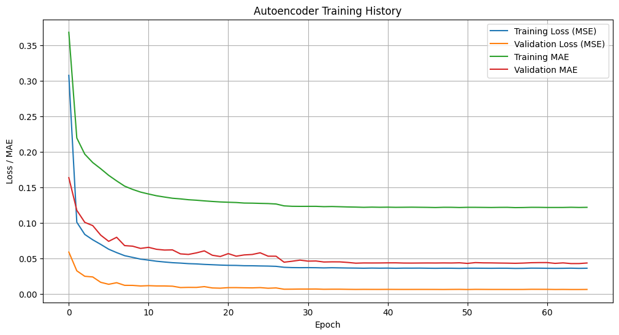

```
Evaluating on validation set after training:
Final Validation MSE: 0.0064
Final Validation MAE: 0.0431
```

```python
# Plot training and validation loss/MAE over epochs
plt.figure(figsize=(12, 6))
plt.plot(history.history['loss'], label='Training Loss (MSE)')
plt.plot(history.history['val_loss'], label='Validation Loss (MSE)')
plt.plot(history.history['mean_absolute_error'], label='Training MAE')
plt.plot(history.history['val_mean_absolute_error'], label='Validation MAE')
plt.title('Autoencoder Training History')
plt.xlabel('Epoch')
plt.ylabel('Loss / MAE')
plt.legend()
plt.grid(True)
plt.show()

# Load the best saved model (due to ModelCheckpoint and EarlyStopping's restore_best_weights)
# If restore_best_weights=True in EarlyStopping, autoencoder already has best weights.
# Otherwise, load explicitly:
# autoencoder = tf.keras.models.load_model('best_autoencoder_model.keras')
# And then recreate the encoder_model if needed, or ensure weights are transferred.
# For simplicity, if using restore_best_weights=True, the current autoencoder and encoder_model are fine.

print("Evaluating on validation set after training:")
# Evaluate the autoencoder on the validation data
val_loss, val_mae = autoencoder.evaluate(X_val, X_val, verbose=0)
print(f"Final Validation MSE: {val_loss:.4f}")
print(f"Final Validation MAE: {val_mae:.4f}")

# Note: The primary goal isn't perfect reconstruction, but rather that the embeddings are useful.
# The validation loss/MAE gives an indication of how well the network generalizes to unseen data.
```

#### 3.5.8 Extract Embeddings

We will use the `encoder_model` to generate embeddings for all properties (the full `item_features_matrix` from the 300k sample).

```python
# Generate embeddings for the entire dataset (300k sample)
all_property_embeddings = encoder_model.predict(item_features_matrix, batch_size=BATCH_SIZE)
print(f"Shape of generated embeddings: {all_property_embeddings.shape}")
# Expected shape: (NUM_SAMPLES, EMBEDDING_DIM) e.g., (300000, 64)

# Save the embeddings
np.save('item_embeddings_300k_nn.npy', all_property_embeddings)
print("Embeddings saved to 'item_embeddings_300k_nn.npy'")

# Also save the encoder model itself for later use
encoder_model.save('encoder_model.keras')
print("Encoder model saved to 'encoder_model.keras'")
```

```
1172/1172 ━━━━━━━━━━━━━━━━━━━━ 1s 1ms/step
Shape of generated embeddings: (300000, 10)
Embeddings saved to 'item_embeddings_300k_nn.npy'
Encoder model saved to 'encoder_model.keras'
```

#### 3.5.9 Calculating Item Similarity in Embedding Space

Now that we have processed our real estate data and used a neural network to generate a numerical representation (an "embedding") for each property, the next crucial step is to determine which properties are similar to each other based on these learned embeddings.

```python
import numpy as np
import pandas as pd
import time
import os
from sklearn.metrics.pairwise import pairwise_distances_chunked

# --- Configuration ---
# Number of similar items to find and store for each item
N_similar = 50

# Size of chunks to process at a time (adjust based on memory and performance)
# This is a conceptual chunk size for processing, sklearn might use different internal chunks
chunk_size = 1000 # Example: Process 1000 source items at a time

# Define filenames
# Input file: The embeddings generated by the neural network
embeddings_filename = 'item_embeddings_300k_nn.npy'
# Output file: Where the Top N similarity results will be saved
embedding_similarity_results_filename = 'item_embedding_similarities_300k.parquet' # Using Parquet for efficiency

# --- Load Item Embeddings ---
try:
    print(f"Loading item embeddings from '{embeddings_filename}'...")
    item_embeddings = np.load(embeddings_filename)
    print(f"Successfully loaded embeddings with shape: {item_embeddings.shape}")
    total_items = item_embeddings.shape[0]
    # Ensure the loaded data is float64 for similarity calculation
    if item_embeddings.dtype != np.float64:
        item_embeddings = item_embeddings.astype(np.float64)
        print(f"Embeddings converted to dtype: {item_embeddings.dtype}")

except FileNotFoundError:
    print(f"Error: Embeddings file '{embeddings_filename}' not found.")
    print("Please ensure the neural network training and embedding extraction steps were run and saved the file.")
    item_embeddings = None # Set to None if file not found
except Exception as e:
    print(f"An error occurred while loading the embeddings: {e}")
    item_embeddings = None

# --- Perform Chunked Similarity Calculation ---
# Only proceed if embeddings were loaded successfully
if item_embeddings is not None:

    # Check if the similarity results file already exists
    if os.path.exists(embedding_similarity_results_filename):
        print(f"Embedding similarity results file '{embedding_similarity_results_filename}' already exists. Reading from file.")
        similarity_df_embeddings = pd.read_parquet(embedding_similarity_results_filename)
        # The list itself is not strictly needed if we load the df,
        # but if other parts of the notebook expect a list:
        # top_n_embedding_similarities_list = similarity_df_embeddings.values.tolist()
        print(f"Loaded {len(similarity_df_embeddings)} embedding similarity pairs.")

    else:
        print(f"\nStarting chunked embedding similarity calculation...")
        print(f"Will find Top {N_similar} similar items per item based on embeddings.")

        top_n_embedding_similarities_list = [] # Initialize list to store results
        start_time = time.time() # Start timing the process
        processed_items_count = 0 # Correctly track items processed as source items

        # pairwise_distances_chunked iterates through item_embeddings (as X) in chunks,
        # comparing each chunk of X against the entirety of item_embeddings (as Y).
        # We use cosine metric (1 - cosine distance)
        for i, distances_chunk in enumerate(pairwise_distances_chunked(
                                                item_embeddings, # Y is implicitly item_embeddings
                                                metric='cosine',
                                                n_jobs=-1, # Use all available CPU cores
                                                working_memory=1024, # Soft limit on memory per thread in MB (adjust as needed)
                                                reduce_func=None # Get the full distance sub-matrix for the chunk
                                            )):
            # distances_chunk is a sub-matrix where rows correspond to the current chunk of embeddings
            # and columns correspond to ALL embeddings.

            # Convert cosine distances to similarities (1 - distance)
            similarities_chunk = 1 - distances_chunk

            # Number of items (rows) in the current chunk from item_embeddings
            num_source_items_in_this_chunk = similarities_chunk.shape[0]

            # Determine the global indices for the source items in THIS specific chunk
            source_item_global_indices = np.arange(
                processed_items_count,
                processed_items_count + num_source_items_in_this_chunk
            )

            # Process each source item in the current chunk
            for local_idx_in_chunk, source_item_global_idx in enumerate(source_item_global_indices):
                # item_similarities is a 1D array of similarities between
                # item_embeddings[source_item_global_idx] and ALL other items in item_embeddings.
                item_similarities = similarities_chunk[local_idx_in_chunk, :]

                # Get indices of similar items, sorted by similarity (descending)
                # argsort sorts in ascending order, so we reverse it
                sorted_indices_all_items = item_similarities.argsort()[::-1]

                # Exclude the item itself (which will have similarity 1.0)
                # The item itself is item_embeddings[source_item_global_idx]
                # Its index in sorted_indices_all_items should be source_item_global_idx
                relevant_sorted_indices = sorted_indices_all_items[sorted_indices_all_items != source_item_global_idx]

                # Get the indices and scores of the Top N similar items
                top_n_target_indices = relevant_sorted_indices[:N_similar]
                top_n_scores = item_similarities[top_n_target_indices]

                # Store the results as (source_item_index, similar_item_index, similarity_score) tuples
                for k_loop_idx in range(len(top_n_target_indices)): # Iterate up to actual number of similar items found (<= N_similar)
                    target_item_global_idx = top_n_target_indices[k_loop_idx]
                    score = top_n_scores[k_loop_idx]
                    top_n_embedding_similarities_list.append((source_item_global_idx, target_item_global_idx, score))

            # Update the count of processed items
            processed_items_count += num_source_items_in_this_chunk

            # Optional: Print progress
            # Print every, say, 10 internal scikit-learn chunks or if all items are processed
            if (i + 1) % 10 == 0 or processed_items_count >= total_items:
                elapsed_time = time.time() - start_time
                estimated_total_time = (elapsed_time / processed_items_count) * total_items if processed_items_count > 0 else 0
                print(f"Processed {processed_items_count}/{total_items} source items. "
                      f"(Internal scikit-learn chunk iteration: {i + 1}). "
                      f"Elapsed: {elapsed_time:.2f}s. Estimated Total: {estimated_total_time:.2f}s")

            # Break the loop if all source items from item_embeddings have been processed
            if processed_items_count >= total_items:
                print("All source items processed.")
                break # Exit the main loop

        end_time = time.time() # End timing
        total_elapsed_time = end_time - start_time

        print(f"\nChunked embedding similarity calculation finished.")
        print(f"Total time taken: {total_elapsed_time:.2f} seconds ({total_elapsed_time/60:.2f} minutes)")
        print(f"Number of embedding similarity pairs stored: {len(top_n_embedding_similarities_list)}")

        # --- Export the Embedding Similarity Results ---
        print(f"Exporting embedding similarity results to '{embedding_similarity_results_filename}'...")
        # Convert the list of tuples to a DataFrame for easy saving
        similarity_df_embeddings = pd.DataFrame(top_n_embedding_similarities_list, columns=['source_item_index', 'similar_item_index', 'similarity_score'])

        # Save the DataFrame to a Parquet file
        try:
            similarity_df_embeddings.to_parquet(embedding_similarity_results_filename, index=False)
            print(f"Embedding similarity results export complete (Parquet format to '{embedding_similarity_results_filename}').")
        except ImportError:
            print("Parquet libraries (pyarrow or fastparquet) not found. Saving to CSV instead.")
            embedding_similarity_results_filename_csv = embedding_similarity_results_filename.replace('.parquet', '.csv')
            similarity_df_embeddings.to_csv(embedding_similarity_results_filename_csv, index=False)
            print(f"Embedding similarity results export complete (CSV format) to '{embedding_similarity_results_filename_csv}').")

    # Ensure similarity_df_embeddings is defined for the next cell, even if loaded from file
    if 'similarity_df_embeddings' not in locals() and 'similarity_df_embeddings' not in globals():
        if os.path.exists(embedding_similarity_results_filename):
            try:
                similarity_df_embeddings = pd.read_parquet(embedding_similarity_results_filename)
                print(f"Loaded {embedding_similarity_results_filename} into similarity_df_embeddings for subsequent cells.")
            except ImportError:
                 print(f"Parquet libraries not found. Cannot load {embedding_similarity_results_filename}.")
                 similarity_df_embeddings = None # Cannot load without libraries
            except Exception as e:
                 print(f"An error occurred while loading {embedding_similarity_results_filename}: {e}")
                 similarity_df_embeddings = None
        else:
            print(f"Error: {embedding_similarity_results_filename} not found and calculation was skipped or failed.")
            # Create an empty DataFrame as a fallback for subsequent cells to not error out immediately
            similarity_df_embeddings = pd.DataFrame(columns=['source_item_index', 'similar_item_index', 'similarity_score'])

else:
    print("\nItem embeddings were not loaded. Skipping embedding similarity calculation.")

# The similarity_df_embeddings DataFrame is now available for the next step (building the lookup).
```

```
Loading item embeddings from 'item_embeddings_300k_nn.npy'...
Successfully loaded embeddings with shape: (300000, 10)
Embeddings converted to dtype: float64

Starting chunked embedding similarity calculation...
Will find Top 50 similar items per item based on embeddings.
Processed 4470/300000 source items. (Internal scikit-learn chunk iteration: 10). Elapsed: 133.38s. Estimated Total: 8951.49s
Processed 8940/300000 source items. (Internal scikit-learn chunk iteration: 20). Elapsed: 240.93s. Estimated Total: 8085.05s
Processed 13410/300000 source items. (Internal scikit-learn chunk iteration: 30). Elapsed: 343.78s. Estimated Total: 7690.85s
Processed 17880/300000 source items. (Internal scikit-learn chunk iteration: 40). Elapsed: 448.90s. Estimated Total: 7531.82s
Processed 22350/300000 source items. (Internal scikit-learn chunk iteration: 50). Elapsed: 550.48s. Estimated Total: 7389.05s
Processed 26820/300000 source items. (Internal scikit-learn chunk iteration: 60). Elapsed: 652.69s. Estimated Total: 7300.73s
Processed 31290/300000 source items. (Internal scikit-learn chunk iteration: 70). Elapsed: 753.66s. Estimated Total: 7225.90s
Processed 35760/300000 source items. (Internal scikit-learn chunk iteration: 80). Elapsed: 854.71s. Estimated Total: 7170.35s
Processed 40230/300000 source items. (Internal scikit-learn chunk iteration: 90). Elapsed: 954.17s. Estimated Total: 7115.36s
Processed 44700/300000 source items. (Internal scikit-learn chunk iteration: 100). Elapsed: 1053.73s. Estimated Total: 7072.03s
Processed 49170/300000 source items. (Internal scikit-learn chunk iteration: 110). Elapsed: 1152.80s. Estimated Total: 7033.57s
Processed 53640/300000 source items. (Internal scikit-learn chunk iteration: 120). Elapsed: 1251.67s. Estimated Total: 7000.40s
Processed 58110/300000 source items. (Internal scikit-learn chunk iteration: 130). Elapsed: 1349.92s. Estimated Total: 6969.11s
Processed 62580/300000 source items. (Internal scikit-learn chunk iteration: 140). Elapsed: 1449.01s. Estimated Total: 6946.33s
Processed 67050/300000 source items. (Internal scikit-learn chunk iteration: 150). Elapsed: 1546.93s. Estimated Total: 6921.39s
Processed 71520/300000 source items. (Internal scikit-learn chunk iteration: 160). Elapsed: 1646.67s. Estimated Total: 6907.16s
Processed 75990/300000 source items. (Internal scikit-learn chunk iteration: 170). Elapsed: 1746.12s. Estimated Total: 6893.48s
Processed 80460/300000 source items. (Internal scikit-learn chunk iteration: 180). Elapsed: 1845.01s. Estimated Total: 6879.24s
Processed 84930/300000 source items. (Internal scikit-learn chunk iteration: 190). Elapsed: 1943.33s. Estimated Total: 6864.48s
Processed 89400/300000 source items. (Internal scikit-learn chunk iteration: 200). Elapsed: 2041.65s. Estimated Total: 6851.19s
Processed 93870/300000 source items. (Internal scikit-learn chunk iteration: 210). Elapsed: 2139.63s. Estimated Total: 6838.07s
Processed 98340/300000 source items. (Internal scikit-learn chunk iteration: 220). Elapsed: 2238.47s. Estimated Total: 6828.76s
Processed 102810/300000 source items. (Internal scikit-learn chunk iteration: 230). Elapsed: 2336.86s. Estimated Total: 6818.97s
Processed 107280/300000 source items. (Internal scikit-learn chunk iteration: 240). Elapsed: 2434.87s. Estimated Total: 6808.92s
Processed 111750/300000 source items. (Internal scikit-learn chunk iteration: 250). Elapsed: 2532.74s. Estimated Total: 6799.29s
Processed 116220/300000 source items. (Internal scikit-learn chunk iteration: 260). Elapsed: 2630.69s. Estimated Total: 6790.62s
Processed 120690/300000 source items. (Internal scikit-learn chunk iteration: 270). Elapsed: 2728.35s. Estimated Total: 6781.88s
Processed 125160/300000 source items. (Internal scikit-learn chunk iteration: 280). Elapsed: 2826.59s. Estimated Total: 6775.14s
Processed 129630/300000 source items. (Internal scikit-learn chunk iteration: 290). Elapsed: 2923.85s. Estimated Total: 6766.61s
Processed 134100/300000 source items. (Internal scikit-learn chunk iteration: 300). Elapsed: 3021.36s. Estimated Total: 6759.20s
Processed 138570/300000 source items. (Internal scikit-learn chunk iteration: 310). Elapsed: 3119.00s. Estimated Total: 6752.54s
Processed 143040/300000 source items. (Internal scikit-learn chunk iteration: 320). Elapsed: 3217.19s. Estimated Total: 6747.46s
Processed 147510/300000 source items. (Internal scikit-learn chunk iteration: 330). Elapsed: 3315.52s. Estimated Total: 6742.98s
Processed 151980/300000 source items. (Internal scikit-learn chunk iteration: 340). Elapsed: 3414.33s. Estimated Total: 6739.70s
```

[output cut: 26 more lines]

```
Processed 272670/300000 source items. (Internal scikit-learn chunk iteration: 610). Elapsed: 10769.58s. Estimated Total: 11849.03s
Processed 277140/300000 source items. (Internal scikit-learn chunk iteration: 620). Elapsed: 10866.76s. Estimated Total: 11763.11s
Processed 281610/300000 source items. (Internal scikit-learn chunk iteration: 630). Elapsed: 10964.62s. Estimated Total: 11680.65s
Processed 286080/300000 source items. (Internal scikit-learn chunk iteration: 640). Elapsed: 11062.68s. Estimated Total: 11600.96s
Processed 290550/300000 source items. (Internal scikit-learn chunk iteration: 650). Elapsed: 11161.26s. Estimated Total: 11524.27s
Processed 295020/300000 source items. (Internal scikit-learn chunk iteration: 660). Elapsed: 11259.46s. Estimated Total: 11449.52s
Processed 299490/300000 source items. (Internal scikit-learn chunk iteration: 670). Elapsed: 11357.71s. Estimated Total: 11377.05s
Processed 300000/300000 source items. (Internal scikit-learn chunk iteration: 672). Elapsed: 11369.75s. Estimated Total: 11369.75s
All source items processed.

Chunked embedding similarity calculation finished.
Total time taken: 11369.76 seconds (189.50 minutes)
Number of embedding similarity pairs stored: 15000000
Exporting embedding similarity results to 'item_embedding_similarities_300k.parquet'...
Embedding similarity results export complete (Parquet format to 'item_embedding_similarities_300k.parquet').
```